# A Practical Framework for Kidney scRNAseq Analysis

Processing and Annotating Kidney scRNAseq Datasets

Nelson Lab

01 August, 2025

# **Introduction**

Single-cell RNA sequencing (scRNAseq) has become an essential tool for profiling the transcriptional landscape of the kidney, enabling the discovery of cell-type-specific responses in health and disease. However, whole kidney snRNAseq datasets present unique challenges due to their cellular complexity, technical variability, and the need for standardized data reporting. Here, we present a practical framework for the analysis, annotation, and deposition of whole kidney snRNAseq datasets. Our approach outlines recommended steps for quality control, ambient RNA removal, detection and removal of doublets in two capacities, and assessment of batch effects. We propose standardized naming conventions for kidney cell types and subtypes, harmonizing nomenclature across studies to promote clarity and reproducibility. Finally, we provide practical guidelines for preparing and depositing processed data and metadata in public repositories such as the Gene Expression Omnibus (GEO), ensuring accessibility and compliance with FAIR (Findable, Accessible, Interoperable, Reusable) data principles. We provide a code and video tutorials to guide investigators through the analysis of a whole kidney snRNAseq dataset starting with a gene by cell matrix through depositing the dataset on GEO. Together, these recommendations aim to foster transparency, reproducibility, and collaborative advancement in kidney research.

## The Goal of This Tutorial

The goal of this tutorial is take a scRNAseq dataset from the **Cell Ranger outputs** stage (cell by gene matrix) to an **accurately annotated seurat object** (.rds file).

## Limitations of This Guide

This tutorial was written to guide the analysis of a **healthy whole kidney dataset**. While many of the same principals apply to analyzing a **diseased whole kidney dataset**, more caution needs to be taken so that diseased cells do not get **inadvertently filtered out** or **incorrectly annotated**.

We **hope** to write future guides on how to approach analyzing **diseased kidney datasets**.

Also, the landscape of **single-cell technologies** is dynamic and improving every day. It’s challenging to set hard thresholds and levels for certain filtering parameters because of this. We hope that the principles underlying this analysis framework stay true, even if the technology and packages used to analyze kidney scRNAseq data evolves.

## Manuscript

A manuscript describing this analysis framework can be found here(broken link).

## Video Tutorial

A video tutorial walking through this analysis framework can be found here(broken link).

## How to Use This R Markdown File

This R markdown file is meant to guide a researcher through the steps of data analysis.

Once you have **analyzed** and **annotated** your dataset and set all the parameters you need to fill out, you can **knit the file**, and it will create an **html report** of your analysis for long-term documentation.

## System Requirements

We have made every effort to reduce the memory burden in this tutorial. However, certain functions are more memory intensive than others (such as **SCTransform**).

Therefore, we recommend performing this tutorial on a computer with at least **16GB of RAM**.

As you analyze more cells (or larger objects), you may need increased amounts of memory (**RAM**) to accommodate computationally heavy functions.

### Resources for Learning R and R Markdown

While beyond the scope of this tutorial, we recommend the following resources for **learning R and R Markdown**:

#### **Blogs and Books**

[R for Data Science (2nd Edition)](https://r4ds.hadley.nz/)  
[R Markdown: The Definitive Guide](https://bookdown.org/yihui/rmarkdown/)  
[R Bloggers](https://www.r-bloggers.com/)  
[Chatomics](https://divingintogeneticsandgenomics.com/)

#### **Online Courses**

[R Programming by Coursera](https://www.coursera.org/learn/r-programming)  
[swi**r**l](https://swirlstats.com/)

#### **Youtube Channels**

Bioinformagician  
[Chatomics](https://www.youtube.com/channel/UC0DNFLi8yg1UVo67bCLMMJg)

# **Create Folders** and **Download Files**

## Create Folder

We suggest creating a folder titled **“Nephronomics”** on your desktop or in a location of your choice. This folder will contain all the files and folders for the analysis. Even though we suggest a title, you can name the file any way you like.

Then, **download the “scRNAseq_guide” RMD file** to follow along, or apply to your own sample [here](https://drive.google.com/file/d/1MJ8pbXAZNocuotPd1iO_TeZKHpETR-jj/view?usp=sharing).

## Create Folder Structure for the Analysis

Ordered file structure is essential to keep track of the files and folders you are working with. This is especially important when working with large datasets, as it can be easy to lose track of files if they are not organized properly.

We will create two folders: **Datasets** and **Outputs**. The Datasets folder will contain the raw and filtered matrices, as well as the metadata file. The Outputs folder will contain the results of the analysis, such as the annotated .rds after analysis.

We utilize the **here() package** in order to create a relative path to the folders. This allows the code to be able to run on any computer without needing to change the file paths (e.g. working directories).

Read more about the **here()** package here

```r
if (!require("here")) {install.packages("here"); require("here")}

Datasets <- "Datasets"
Outputs <- "Outputs"

if (!dir.exists(here(Datasets))) {dir.create(here(Datasets))}
if (!dir.exists(here(Outputs))) {dir.create(here(Outputs))}

#tree "/Users/omidsajjadi/Desktop/Nephronomics" /F
```

## **Download** Tutorial Datasets

**Download** the tutorial dataset to walk through in this guide:  
Download the [raw matrix](https://drive.google.com/file/d/1WE7LdTv3RW0wtN6pazxxe_yBb7gNA4Wl/view?usp=sharing)  
Download the [filtered matrix](https://drive.google.com/file/d/1dJM2PvYzzvH0JRgzw-uLfbidkib3CihV/view?usp=sharing)  
Download the [metadata file](https://docs.google.com/spreadsheets/d/1bzxRAlDTFKC9u-hE7-Ejz5GqnqH_2spB/edit?usp=sharing&ouid=100835342690409949441&rtpof=true&sd=true)

### **Place** the raw matrix, filtered matrix, and metadata files in the **Datasets folder**.

### Your folder structure should look like this:

**NEPHRONOMICS**  
│ snRNAseq_guide.Rmd  
│  
│ - - - **Datasets**  
│ 7_filtered_feature_bc_matrix.h5  
│ 7_raw_feature_bc_matrix.h5  
│ metadata.xlsx  
│  
│ - - - **Outputs**

# **Install and Load** Packages

### The packages below may need to be installed for the first time you run this code.

#### The following are packages are not on CRAN or Bioconductor and can be installed using the remotes::install_github() function or devtools::install_github() function.

Simply **remove the hashtags** to run the code and install packages for the first time. After the packages are installed, you can comment out the code again by **adding the hashtags at the beginning of each line**.

```r
#install.packages("remotes")
#remotes::install_github('chris-mcginnis-ucsf/DoubletFinder', force = TRUE)

#install.packages("devtools")
#devtools::install_github("davidsjoberg/ggsankey")
```

#### The following packages are on CRAN or Bioconductor and can be installed using the install.packages() function or BiocManager::install() function.

```r
if (!require("dplyr")) {install.packages("dplyr"); require("dplyr")}
if (!require("Seurat")) {install.packages("Seurat"); require("Seurat")}
if (!require("patchwork")) {install.packages("patchwork"); require("patchwork")}
if (!require("cowplot")) {install.packages("cowplot"); require("cowplot")}
if (!require("ggpubr")) {install.packages("ggpubr"); require("ggpubr")}
if (!require("plotly")) {install.packages("plotly"); require("plotly")}
if (!require("knitr")) {install.packages("knitr"); require("knitr")}
if (!require("htmlwidgets")) {install.packages("htmlwidgets"); require("htmlwidgets")}
if (!require("tidyverse")) {install.packages("tidyverse"); require("tidyverse")} # for titying up data
if (!require("RColorBrewer")) {install.packages("RColorBrewer"); require("RColorBrewer")} # for color brewer
if (!require("sctransform")) {install.packages("sctransform"); require("sctransform")} # for data normalization
if (!require("openxlsx")) {install.packages("openxlsx"); require("openxlsx")} # to save .xlsx files
if (!require("SoupX")) {install.packages("SoupX"); require("SoupX")}
if (!require("readxl")) {install.packages("readxl"); require("readxl")}
if (!require("hdf5r")) {install.packages("hdf5r"); require("hdf5r")}

if (!require("glmGamPoi")) {BiocManager::install('glmGamPoi'); require("glmGamPoi")} # for data normalization, sctransform
if (!require("EnhancedVolcano")) {BiocManager::install('EnhancedVolcano'); require("EnhancedVolcano")} # volcano plot

library(ggsankey)
library(DoubletFinder)

set.seed(12345)
here()
```

# **Load Dataset**

## Set the Sample Name

This will be used to automate the addition of **metadata** to the Seurat object and to save output files (**DEG lists and Seurat Object**).

```r
sample_name <- "WholeMouseKidney7" # Replace with your sample name
```

```r
# Create a Soup Channel Object(sc) to use for future filtering of ambient RNA
RawDataset = Read10X_h5(here("Datasets", "7_raw_feature_bc_matrix.h5"))
FilteredDataset = Read10X_h5(here("Datasets", "7_filtered_feature_bc_matrix.h5"))

# Make a Seurat Object from the filtered control data
filtered_kidney <- Read10X_h5(here("Datasets", "7_filtered_feature_bc_matrix.h5"))
filtered_kidney <- CreateSeuratObject(counts = filtered_kidney, project = "Filteredkidney_snRNA")
```

### If it doesn’t, **check** the location of your files and if you **activated** the here package

# **SoupX**

**SoupX** is an R package designed to identify and remove ambient RNA contamination from droplet-based single-cell RNA sequencing (scRNAseq) data. Ambient RNA, freely floating transcripts that are captured non-specifically during droplet formation, can distort downstream analyses by falsely inflating gene expression levels, particularly in low-UMI cells or empty droplets. SoupX models this “soup” contamination by first estimating the background expression profile from low-UMI droplets that are likely empty. It then uses this ambient RNA profile to adjust gene expression values in cell-containing droplets, accounting for contamination in a probabilistic and gene-specific manner.

When you run `autoEstCont(sc)` in SoupX, it automatically estimates the contamination fraction (rho) by comparing the expression of known marker genes in presumed “pure” cell types. The graph output typically includes a plot of the model fit, showing observed versus expected expression for these genes across a range of contamination fractions. The point where the model best matches the observed data is used to estimate the contamination rate. A good fit suggests that the estimated contamination fraction accurately captures the ambient RNA contribution, and the plot can help assess whether the correction is likely to be reliable.

[soupx Manuscript](https://pubmed.ncbi.nlm.nih.gov/33367645/)  
[soupx Github](https://github.com/constantAmateur/SoupX)  
[soupx Tutorial](https://rawcdn.githack.com/constantAmateur/SoupX/204b602418df12e9fdb4b68775a8b486c6504fe4/inst/doc/pbmcTutorial.html)

```r
sc = SoupChannel(RawDataset,FilteredDataset)

# Cluster the Cells with Seurat
filtered_kidney <- SCTransform(filtered_kidney, verbose = F)
filtered_kidney <- RunPCA(filtered_kidney, verbose = F)
filtered_kidney <- RunUMAP(filtered_kidney, dims = 1:40, verbose = F)
filtered_kidney <- FindNeighbors(filtered_kidney, dims = 1:40, verbose = F)
filtered_kidney <- FindClusters(filtered_kidney, verbose = F)

meta <- filtered_kidney@meta.data
umap <- filtered_kidney@reductions$umap@cell.embeddings
clusters <- setNames(meta$seurat_clusters, rownames(meta))

#Ensure the two following numbers are equal before continuing
check1 <- length(clusters)
check2 <- nrow(sc$metaData)

sc <- setClusters(sc, clusters)
sc <- setDR(sc, umap)
```

## Estimation of **WholeMouseKidney7** Ambient RNA levels

```r
sc = autoEstCont(sc)
```

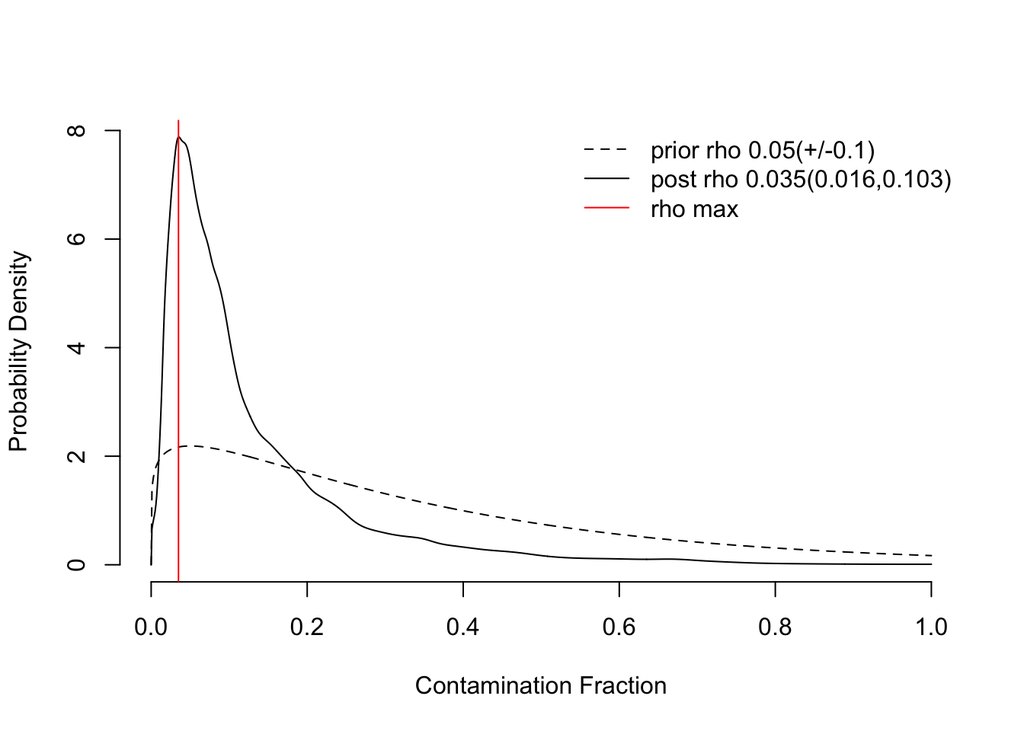

```r
x <- sc$fit$rhoEst * 100
y <- sc$fit$rhoFWHM * 100
#in bad datasets the peak is
```

This post rho value is **3.5%** with a FWHM of **1.6% - 10.3%** . This means that your estimated amount of ambient RNA is **3.5%**.

### **WARNING:** Ambient RNA

Ambient RNA levels are acceptable.

```r
#Clean the data
filtered_kidney_out = adjustCounts(sc)

#Create a new Seurat Object out of the cleaned data
seurat.obj <- CreateSeuratObject(filtered_kidney_out)

# Remove unused objects in environment to save RAM

#rm(filtered_kidney, filtered_kidney_out, FilteredDataset, RawDataset, sc, meta, check1, check2, clusters, umap, y, Datasets, Outputs)
```

# **DoubletFinder**

**DoubletFinder** is an R package used to detect and remove doublets; droplets that have captured two or more cells instead of one, from single-cell RNA-seq datasets. Doublets can introduce misleading hybrid transcriptional profiles, impacting clustering, differential expression, and trajectory inference. DoubletFinder works by generating artificial doublets from real cell profiles and then identifying real cells that resemble these artificial profiles. It embeds both real and artificial cells in a reduced-dimensional space (usually PCA), computes each cell’s neighborhood density of artificial doublets (pANN score), and uses that to rank the likelihood that each real cell is a doublet.

After running DoubletFinder, you’ll typically interpret results by examining the metadata field `DF.class`, which labels each cell as “Doublet” or “Singlet.” You can visualize the results using dimensionality reduction plots (e.g., UMAP), coloring cells by their classification to check whether doublets cluster separately or are enriched in certain regions. The `pANN` score itself is a continuous value indicating how doublet-like a cell is, which is useful for threshold tuning. The expected doublet rate, often informed by cell loading density and 10X Genomics guidelines, plays a critical role in setting the classification cutoff.

## Important Note

You set the **expected rate of doublets** when using DoubletFinder. This is often set as the rate of doublets **[published by 10x genomics](https://kb.10xgenomics.com/hc/en-us/articles/360001378811-What-is-the-maximum-number-of-cells-that-can-be-profiled-)** based on their microfluidic device. But this rate does **NOT** account for an **resulting from poor sample preparation**.

[DoubletFinder Manuscript](https://www.ncbi.nlm.nih.gov/pmc/articles/PMC6853612/)  
[DoubletFinder Github](https://github.com/chris-mcginnis-ucsf/DoubletFinder)

## Filtering of Low Complexity Cells

This step serves to filter out droplets that may have **inadvertently** been determined as cells by CellRanger (or other demultiplexing applications).

Not filtering out the empty droplets will interfere with doublet detection downstream.

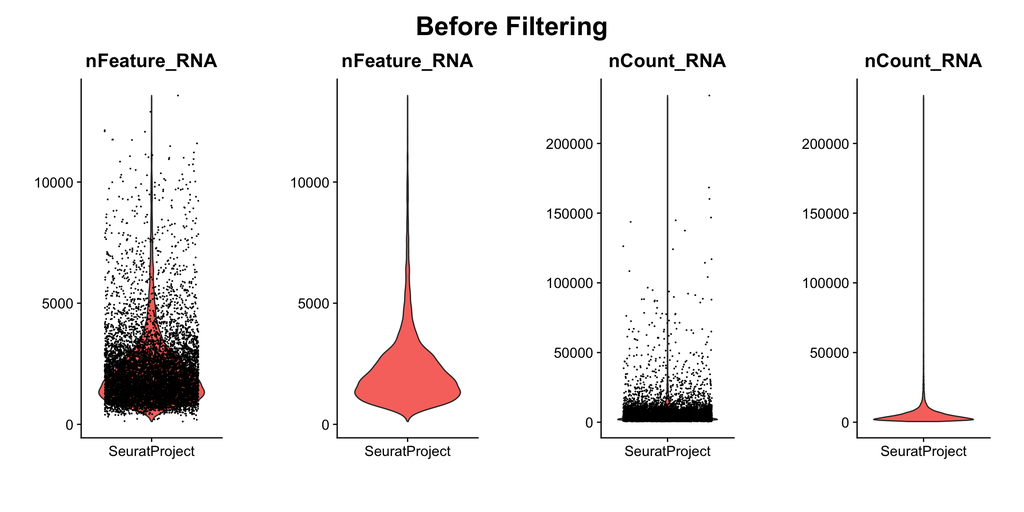

```r
Start <- ncol(seurat.obj)

p1 <- VlnPlot(seurat.obj, features = c("nFeature_RNA")) + theme(axis.title.x = element_blank()) + theme(legend.position = 'none') + theme(axis.text.x = element_text(angle = 0, hjust = .5))

p2 <- VlnPlot(seurat.obj, features = c("nFeature_RNA"), pt.size = 0) + theme(axis.title.x = element_blank()) + theme(legend.position = 'none') + theme(axis.text.x = element_text(angle = 0, hjust = .5))

p3 <- VlnPlot(seurat.obj, features = c("nCount_RNA")) + theme(axis.title.x = element_blank())  + theme(legend.position = 'none') + theme(axis.text.x = element_text(angle = 0, hjust = .5))

p4 <- VlnPlot(seurat.obj, features = c("nCount_RNA"), pt.size = 0) + theme(axis.title.x = element_blank())  + theme(legend.position = 'none') + theme(axis.text.x = element_text(angle = 0, hjust = .5))

cowplot::plot_grid(p1, p2, p3, p4, ncol = 4, scale = .85) + draw_label("Before Filtering", y = .95, size = 22, fontface = "bold")
```

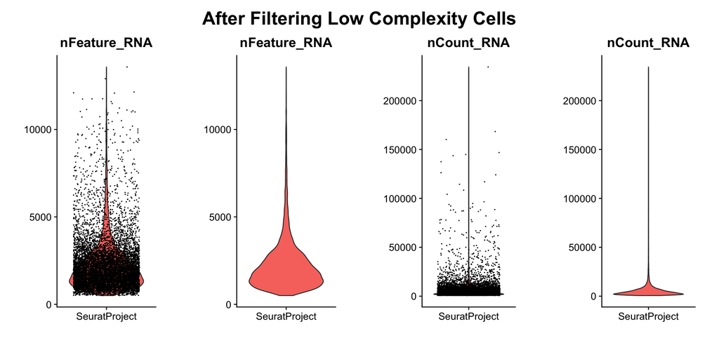

```r
# Minimal filtering of low quality cells
seurat.obj.f <- subset(seurat.obj, nFeature_RNA > 500)

p1 <- VlnPlot(seurat.obj.f, features = c("nFeature_RNA")) + theme(axis.title.x = element_blank()) + theme(legend.position = 'none') + theme(axis.text.x = element_text(angle = 0, hjust = .5))

p2 <- VlnPlot(seurat.obj.f, features = c("nFeature_RNA"), pt.size = 0) + theme(axis.title.x = element_blank()) + theme(legend.position = 'none') + theme(axis.text.x = element_text(angle = 0, hjust = .5))

p3 <- VlnPlot(seurat.obj.f, features = c("nCount_RNA")) + theme(axis.title.x = element_blank())  + theme(legend.position = 'none') + theme(axis.text.x = element_text(angle = 0, hjust = .5))

p4 <- VlnPlot(seurat.obj.f, features = c("nCount_RNA"), pt.size = 0) + theme(axis.title.x = element_blank())  + theme(legend.position = 'none') + theme(axis.text.x = element_text(angle = 0, hjust = .5))

cowplot::plot_grid(p1, p2, p3, p4, ncol = 4, scale = .85) + draw_label("After Filtering Low Complexity Cells", y = .95, size = 22, fontface = "bold")
```

```r
Filter_1 <- ncol(seurat.obj.f)

amountfiltered1 <- Start-Filter_1

#Making a table to display the amount of cells being filtered out with the minimal filtering of low quality cells applied to the snRNAseq dataset.
cell_counts <- data.frame(Phase = c("Before Filtering", "After Filtering", "Amount Filtered"), Cell_Number = c(Start, Filter_1, amountfiltered1))

print(cell_counts)

# Remove unused objects in environment to save RAM

#rm(seurat.obj, p1, p2, p3, p4, cell_counts)
```

**72 cells** were removed after **filtering low-complexity cells**.

## High-Dimentional Superclustering

### Set the Resolution

```r
resolution_value <- 2.0 # Set the resolution value for clustering
```

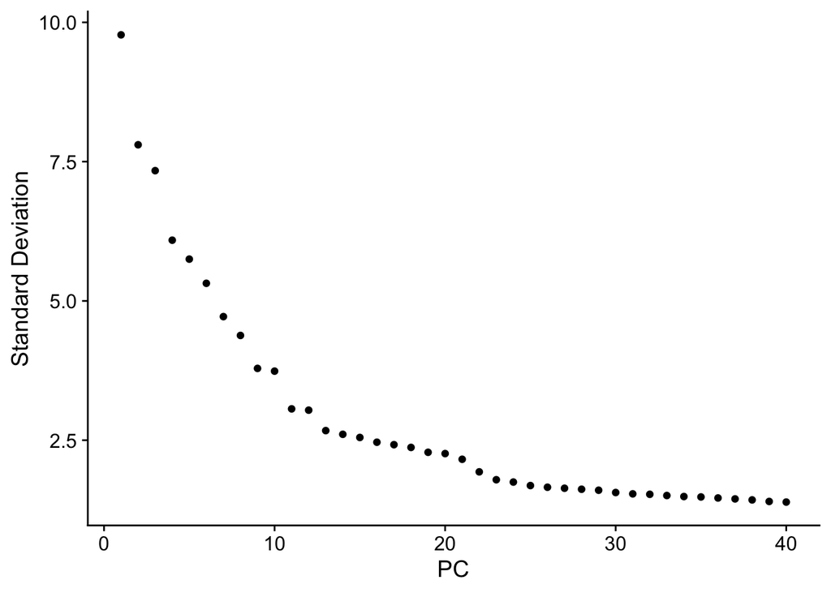

```r
# Pre-process standard workflow
seurat.obj.f <- NormalizeData(object = seurat.obj.f)
seurat.obj.f <- FindVariableFeatures(object = seurat.obj.f)
seurat.obj.f <- ScaleData(object = seurat.obj.f)
seurat.obj.f <- RunPCA(object = seurat.obj.f)

ElbowPlot(seurat.obj.f, ndims = 40)
```

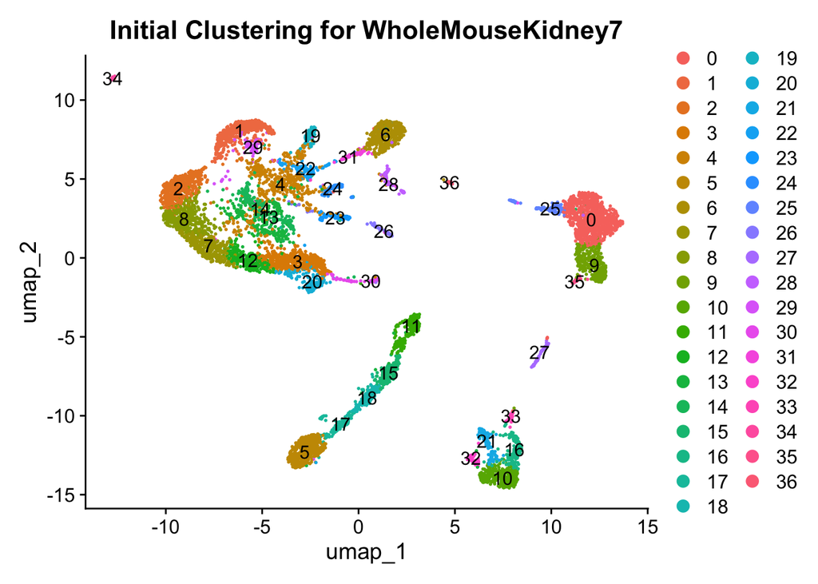

```r
seurat.obj.f <- FindNeighbors(object = seurat.obj.f, dims = 1:40)
seurat.obj.f <- FindClusters(object = seurat.obj.f, resolution = resolution_value, verbose = F)

# Make a UMAP to visualize the clusters
seurat.obj.f <- RunUMAP(object = seurat.obj.f, dims = 1:40)
DimPlot(seurat.obj.f, reduction = "umap", label = TRUE) +
   theme(plot.title = element_text(hjust = 0.5)) +
   ggtitle(paste0("Initial Clustering for ", sample_name))
```

The continuation of clusters from Distal Convoluted Tubule 1 to Principal Cells is the aim of each umap visualization throughout the analysis. The multidimensional dot plot allows for more insight into confirmation of this flow.

## Save Excel Spreadsheet

### This code creates an Excel Spreadsheet of DEG List by Cluster

This file can be used to determine the **prominent features** (highly enriched genes) of each cluster.

The file will be located in the **Outputs** folder.

```r
all_markers <- FindAllMarkers(seurat.obj.f, only.pos = TRUE, min.pct = 0.5, logfc.threshold = 1)

# Order by avg_log2FC
all_markers <- all_markers %>%
  arrange(desc(avg_log2FC)) %>%
  select(gene, everything())

# Split by cluster (ident column)
marker_list <- split(all_markers, all_markers$cluster)

# Sort names alphanumerically
sorted_cluster_names <- names(marker_list)[order(as.numeric(names(marker_list)))]

# Create a workbook
wb <- createWorkbook()

# Add each cluster as a new worksheet
for (cluster_name in sorted_cluster_names) {
  addWorksheet(wb, sheetName = cluster_name)
  writeData(wb, sheet = cluster_name, marker_list[[cluster_name]])
}

date <- format(Sys.Date(), "%Y%m%d")

# Save workbook
saveWorkbook(wb, here("Outputs", paste0(date, "_", sample_name, "_FindAllMarkers_By_Cluster.xlsx")), overwrite = TRUE)
```

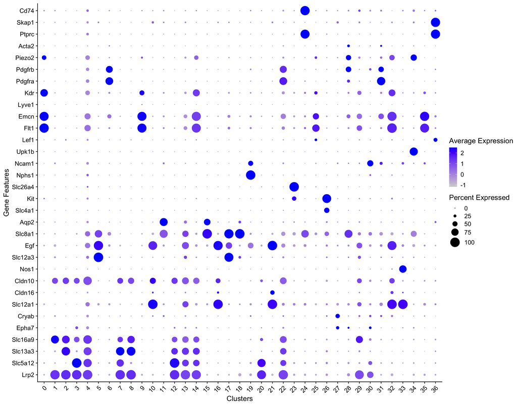

```r
cell_type_markers_df <- data.frame(
  Subclass = c(
    "PTS1", "PTS2", "PTS3", "DTL", "TALA", "TALB", "MD", "DCT1", "DCT2", "CNT",
    "PC", "ICA", "ICB", "PODO", "PEC", "URO", "EC", "LYMPH", "FIB", "MES", "VSMC", "LYMPHO", "MACRO"
  ),
  Positive_Marker_1 = c(
    "Lrp2", "Lrp2", "Lrp2", "Epha7", "Slc12a1", "Slc12a1", "Nos1", "Slc12a3", "Slc12a3", "Slc8a1",
    "Aqp2", "Slc4a1", "Slc26a4", "Nphs1", "Ncam1", "Upk1b", "Flt1", "Lyve1", "Pdgfra", "Pdgfrb", "Pdgfrb", "Ptprc", "Ptprc"
  ),
  Positive_Marker_2 = c(
    "Slc5a12", "Slc13a3", "Slc16a9", "Cryab", "Cldn16", "Cldn10", "Slc12a1", "Egf", "Slc8a1", NA,
    NA, "Kit", NA, NA, NA, NA, "Emcn", "Kdr", "Pdgfrb", "Piezo2", "Acta2", "Skap1", "Cd74"
  ),
  stringsAsFactors = FALSE
)

# Creating a dot plot to cross reference the features with the cell clusters present, seeing the average expression and percent expressed

markers.to.plot1 <- c("Lrp2",         # PTS1, PTS2, PTS3
                      "Slc5a12",      # PTS1
                      "Slc13a3",      # PTS2
                      "Slc16a9",      # PTS3
                      "Epha7",        # DTL
                      "Cryab",        # DTL
                      "Slc12a1",      # TAL1, TAL2, MD
                      "Cldn16",       # TAL1
                      "Cldn10",       # TAL2
                      "Nos1",         # MD
                      "Slc12a3",      # DCT1, DCT2
                      "Egf",          # DCT1
                      "Slc8a1",       # CNT, DCT2
                      "Aqp2",         # PC
                      "Slc4a1",       # ICA
                      "Kit",          # ICA
                      "Slc26a4",      # ICB
                      "Nphs1",        # PODO
                      "Ncam1",        # PEC
                      "Upk1b",        # URO
                      "Lef1",         # ECG
                      "Flt1",         # ECP
                      "Emcn",         # ECP
                      "Lyve1",        # LYMPH
                      "Kdr",          # LYMPH
                      "Pdgfra",       # FIB
                      "Pdgfrb",       # FIB, MES, VSMC
                      "Piezo2",       # MES
                      "Acta2",        # VSMC
                      "Ptprc",        # LYMPHO, MACRO
                      "Skap1",        # LYMPHO
                      "Cd74"         # MACRO
)

p1 <- DotPlot(seurat.obj.f,
features = markers.to.plot1,
dot.scale = 8,
dot.min = 0,
scale.max = 100,
scale.min = 0,
col.min = -2.5,
col.max = 2.5) +
  theme(axis.text.x = element_text(angle = 45, hjust = 1)) +
  coord_flip() +
  labs(x = "Gene Features", y = "Clusters")

p1
```

## Cell Types of Concern

```r
p2 <- as.data.frame(p1$data)

low_pct_features <- p2 %>%
  group_by(features.plot) %>%
  filter(all(pct.exp <= 75)) %>%
  distinct(features.plot) %>%
  pull(features.plot)

# low_pct_features

low_pct_features2 <- as.data.frame(low_pct_features)

markers_long <- cell_type_markers_df %>%
  pivot_longer(cols = c(Positive_Marker_1, Positive_Marker_2),
               names_to = "marker_type", values_to = "marker") %>%
  filter(!is.na(marker))  # remove any NAs in marker

# Step 2: Join with low_pct_features2
low_pct_features2_annotated <- low_pct_features2 %>%
  left_join(markers_long, by = c("low_pct_features" = "marker")) %>%
  rename(cell_type = Subclass)  # rename Subclass to cell_type

missing_cell_types <- unique(na.omit(low_pct_features2_annotated$cell_type))

missing_cell_types
```

### **WARNING:** Missing Cell Types

The following features were found to have less than 75% of the cells expressing them in the any clusters: **Epha7, Cryab, Cldn16, Slc4a1, Ncam1, Lef1, Lyve1, Pdgfrb, Piezo2, Acta2**.

This may make it challenging to identify the following subclasses in this dataset: **DTL, TALA, ICA, PEC, LYMPH, FIB, MES, VSMC**.

#### **Options 1**: Run the chunk below and see if there are any clusters that are clearly enriched for the cell-type defining markers.

```r
for (i in low_pct_features) {

  # Find the subclass (if any) where the marker matches Positive_Marker_1 or _2
  subclass_match <- cell_type_markers_df %>%
    filter(Positive_Marker_1 == i | Positive_Marker_2 == i) %>%
    pull(Subclass)

  # If found, use the first match; else NA
  subclass_label <- if (length(subclass_match) > 0) subclass_match[1] else NA

  # Build the title
  title_text <- if (!is.na(subclass_label)) {
    paste0(i, " (", subclass_label, ")")
  } else {
    i
  }

  # Create plot
  p <- FeaturePlot(seurat.obj.f, features = i) &
       scale_colour_gradientn(colours = rev(brewer.pal(n = 9, name = "RdYlBu"))) &
       ggtitle(title_text)

  print(p)  # Or save/store as needed
}
```

#### **Option 2**: Go to the **`High-Dimensional Superclustering`** Chunk and increase the resolution (e.g. change from “2” to “3”), and see if you are able to see clear clusters for missing cell types.

## Continue With DoubletFinder

```r
# PCs set to 1:20 since it was between 15-20 on the earlier elbow plot
sweep.res.list_seurat.obj.f <- paramSweep(seurat.obj.f, PCs = 1:20, sct = FALSE)
```

```r
#Summarize each combination of pN and pK
sweep.stats_seurat.obj.f <- summarizeSweep(sweep.res.list_seurat.obj.f, GT = FALSE)

#Select the pK that corresponds to max bcmvn to optimize doublet detection
bcmvn_seurat.obj.f <- find.pK(sweep.stats_seurat.obj.f)
```

```r
pK <- bcmvn_seurat.obj.f %>%
  filter(BCmetric == max(BCmetric)) %>%
  select(pK)

#See pK in the Values Environment
pK <- as.numeric(as.character(pK[[1]]))
```

```r
# Homotypic Doublet Proportion Estimate -------------------------------------------------------------------------------------
annotations <- seurat.obj.f@meta.data$seurat_clusters

homotypic.prop <- modelHomotypic(annotations)

# 10X Multiplet Rate Table (the doublet ratio is # of cells recovered divided by 125000) https://kb.10xgenomics.com/hc/en-us/articles/360001378811-What-is-the-maximum-number-of-cells-that-can-be-profiled-

nExp_poi <- round(nrow(seurat.obj.f@meta.data) # To calculate cell number
                  /125000              # To calculate the doublet ratio
                  *nrow(seurat.obj.f@meta.data))

nExp_poi_adj <- round(nExp_poi*(1-homotypic.prop))
```

```r
seurat.obj.f_doublets <- doubletFinder(seurat.obj.f,
                        PCs = 1:20,
                        pN = 0.25,
                        pK = pK,
                        nExp = nExp_poi_adj,
                        reuse.pANN = NULL, sct = FALSE)

# Change names of columns for future analysis
colnames(seurat.obj.f_doublets@meta.data)[grep("^pANN", colnames(seurat.obj.f_doublets@meta.data))] <- "pANN"
colnames(seurat.obj.f_doublets@meta.data)[grep("^DF.class", colnames(seurat.obj.f_doublets@meta.data))] <- "DF.class"

seurat.obj.f_doublets@meta.data$DF.class <- factor(
  seurat.obj.f_doublets@meta.data$DF.class,
  levels = c("Singlet", "Doublet")
)
table(seurat.obj.f_doublets@meta.data$DF.class)

# Make a value for the doublet count to include in the analysis
doublet_count <- table(seurat.obj.f_doublets@meta.data$DF.class)["Doublet"]
```

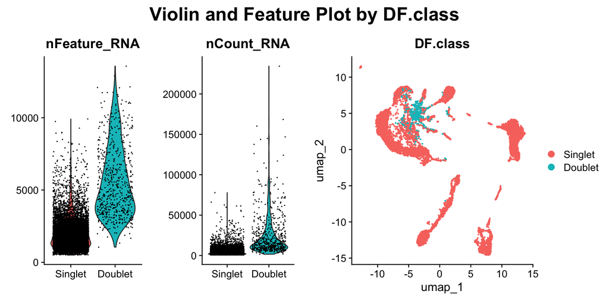

```r
p1 <- VlnPlot(seurat.obj.f_doublets, features = c("nFeature_RNA"), group.by = "DF.class") +
  theme(axis.title.x = element_blank(),
        legend.position = 'none',
        axis.text.x = element_text(angle = 0, hjust = .5))

p2 <- VlnPlot(seurat.obj.f_doublets, features = c("nCount_RNA"), group.by = "DF.class") +
  theme(axis.title.x = element_blank(),
        legend.position = 'none',
        axis.text.x = element_text(angle = 0, hjust = .5))

p3 <- DimPlot(seurat.obj.f_doublets, group.by = "DF.class")

grid <- plot_grid(p1, p2, p3, ncol = 3, align = "h", axis = "tb", rel_widths = c(1, 1, 2))

plot_grid(
  ggdraw() + draw_label("Violin and Feature Plot by DF.class", fontface = 'bold', size = 22, hjust = 0.5),
  grid,
  ncol = 1,
  rel_heights = c(0.1, 1)
)
```

## Visualization of Singlet Object

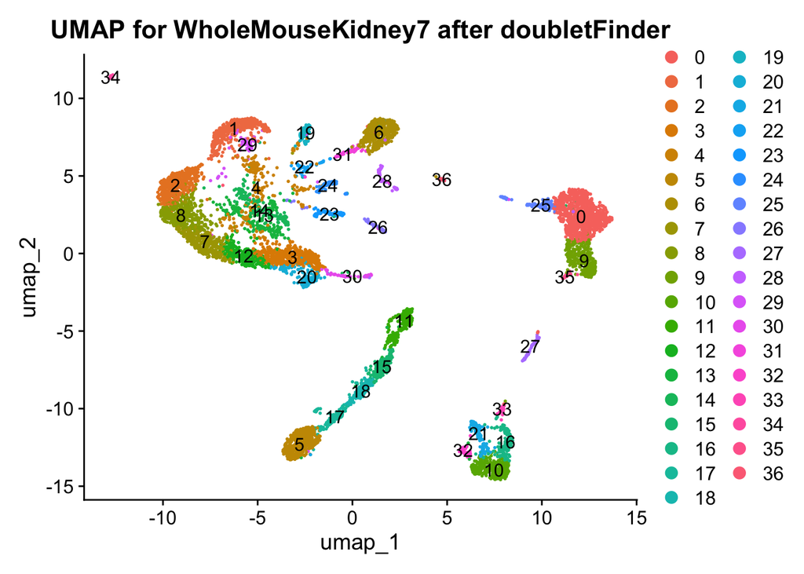

```r
seurat.obj.f_singlets <- subset(seurat.obj.f_doublets, DF.class == "Singlet")

DimPlot(seurat.obj.f_singlets, reduction = "umap", label = T)+
   theme(plot.title = element_text(hjust = 0.5)) +
   ggtitle(paste0("UMAP for ", sample_name, " after doubletFinder"))
```

## Number of Cells Filtered

```r
Filter_2  <- ncol(seurat.obj.f_singlets)

amountfiltered2 <- Filter_1-Filter_2

#Making a table to display the amount of cells being filtered out with the minimal filtering of low quality cells applied to the snRNAseq dataset.
cell_counts <- data.frame(Phase = c("Before Filtering", "After Filtering", "Amount Filtered"), Cell_Number = c(Filter_1, Filter_2, amountfiltered2))

print(cell_counts)

# Remove unused objects in environment to save RAM
# rm(seurat.obj.f, seurat.obj.f_doublets, sweep.res.list_seurat.obj.f, sweep.stats_seurat.obj.f, p, p1, p2)
```

**592 cells** were removed after **doubletFinder**.

# **Manual** Doublet Filtering

A multidimensional dot plot of known cell type markers is a powerful manual curation tool used to assess the biological validity of clusters in single-cell or single-nucleus RNAseq data. By plotting the expression of canonical marker genes across all clusters; using `DotPlot()` in Seurat, researchers can visualize both the average expression (**color**) and the proportion of expressing cells (**dot size**) for each marker. This approach allows for rapid identification of clusters that express expected marker combinations for defined cell types (e.g., Nphs2 for podocytes, Lrp2 for proximal tubule), as well as clusters with conflicting or non-specific expression patterns.

Clusters that show co-expression of markers from multiple, unrelated lineages (e.g., endothelial and immune markers) or lack strong expression of any canonical markers are often flagged as poor-quality or artifactual. These clusters may represent doublets or low-quality cells. Manual removal of such clusters, guided by marker expression patterns rather than purely unsupervised algorithms, can significantly improve dataset interpretability and ensure more biologically meaningful downstream analyses. However, this **process requires domain expertise** and should be applied with care.

### The Goal of This Step Is To Remove Doublets Not Identified by doubletFinder

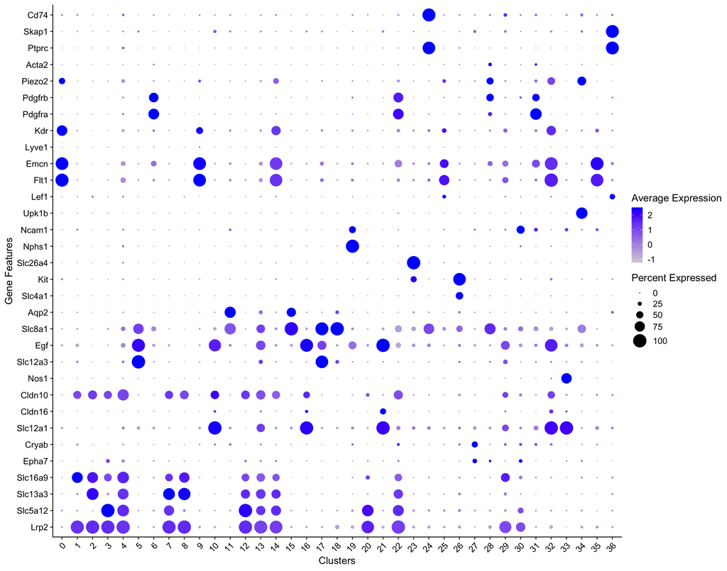

```r
# Creating a dot plot to cross reference the features with the cell clusters present, seeing the average expression and percent expressed

f1 <- DotPlot(seurat.obj.f_singlets,
features = markers.to.plot1,
dot.scale = 8,
dot.min = 0,
scale.max = 100,
scale.min = 0,
col.min = -2.5,
col.max = 2.5) +
  theme(axis.text.x = element_text(angle = 45, hjust = 1)) +
  coord_flip() +
  labs(x = "Gene Features", y = "Clusters")

f1
```

## Clusters of Concern

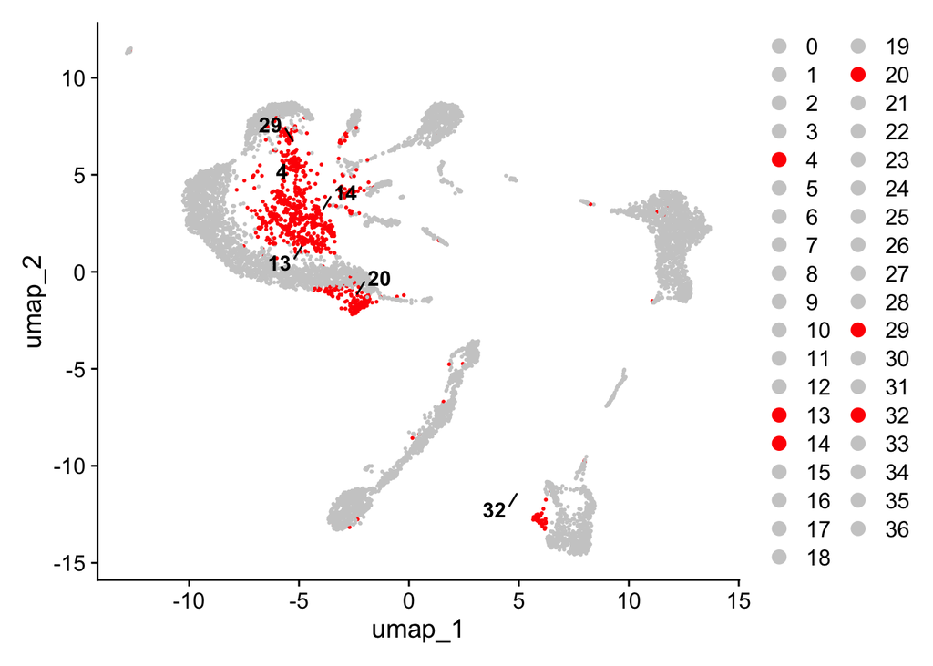

```r
f2 <- as.data.frame(f1$data)

maybe_doublets <- f2 %>%
  group_by(id) %>%
  filter(all(avg.exp.scaled <= 2.0)) %>%
  distinct(id) %>%
  pull(id)

maybe_doublets

# Create color palette: grey for all, color for maybe_doublets
all_clusters <- levels(seurat.obj.f_singlets)
cluster_colors <- setNames(rep("grey80", length(all_clusters)), all_clusters)
cluster_colors[maybe_doublets] <- "red"

# Get UMAP coordinates and cluster assignments
umap_data <- Embeddings(seurat.obj.f_singlets, "umap") %>%
  as.data.frame() %>%
  mutate(cluster = Idents(seurat.obj.f_singlets))

# Compute cluster centroids
cluster_centroids <- umap_data %>%
  group_by(cluster) %>%
  summarise(UMAP_1 = mean(umap_1), UMAP_2 = mean(umap_2))

# Keep only centroids for maybe_doublets
label_data <- cluster_centroids %>%
  filter(cluster %in% maybe_doublets)

# Plot
DimPlot(seurat.obj.f_singlets, reduction = "umap", cols = cluster_colors) +
  ggrepel::geom_text_repel(
    data = label_data,
    aes(x = UMAP_1, y = UMAP_2, label = cluster),
    size = 4,
    color = "black",
    fontface = "bold",
    max.overlaps = Inf,
    box.padding = 0.5,
    point.padding = 0.5
  )
```

## **WARNING!** Clusters of Concern

Some clusters present are doublets, and one can identify such, as they express various gene markers with a low average expression.

It is vital to refer back to the multidimensional dot plot to ensure that the identity of the clusters as maybe doublets aligns with the data present in the plot. Here, it appears that clusters **4, 13, 14, 20, 29, 32** are still potential doublets in the dataset after previous removal.

```r
# Apply the name "SINGLET" or "DOUBLET" to a cluster based on the multidimensional dot plot

doublet_clusters <- c(29, 4, 13, 14)

# Annotate metadata
seurat.obj.f_singlets@meta.data <- seurat.obj.f_singlets@meta.data %>%
  mutate(subclass.doublet = if_else(
    seurat_clusters %in% doublet_clusters, "DOUBLET", "SINGLET"
  ))

# Change the identities to align with new subclass names and make umap
Idents(seurat.obj.f_singlets) <- seurat.obj.f_singlets@meta.data$subclass.doublet

f1 <- DimPlot(seurat.obj.f_singlets, reduction = "umap") +
  theme(plot.title = element_text(hjust = 0.5)) +
  ggtitle("Before Manual Doublet Filtering")
```

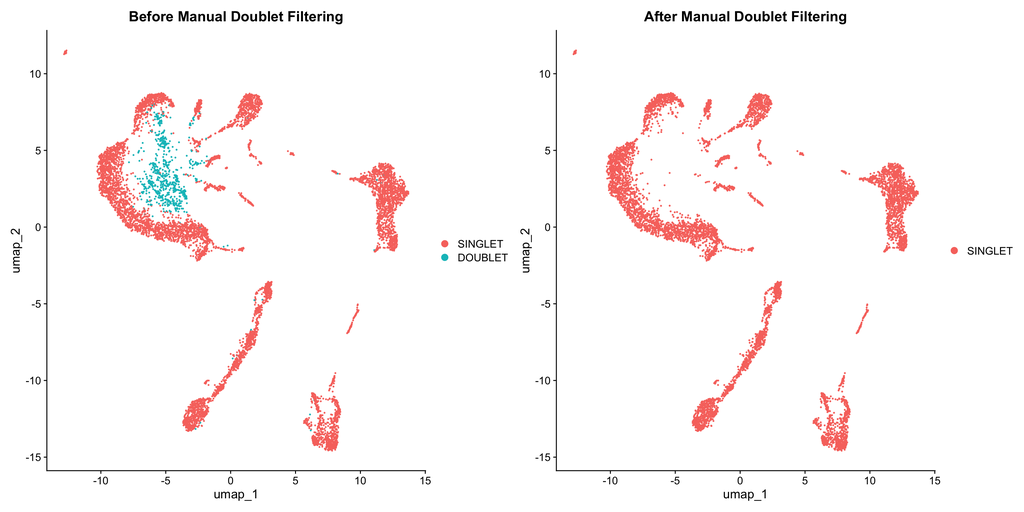

```r
# Double check the table to ensure SINGLET & DOUBLET cluster appear with this function
table(Idents(seurat.obj.f_singlets))

# Clean out the doublets manually that were identified
seurat.obj.f_cleaned <- subset(seurat.obj.f_singlets, idents = "DOUBLET", invert = TRUE)

# Double check that the identity was removed
table(Idents(seurat.obj.f_cleaned))

# Make umap to double check removal
f2 <- DimPlot(seurat.obj.f_cleaned, reduction = "umap") +
  theme(plot.title = element_text(hjust = 0.5)) +
  ggtitle("After Manual Doublet Filtering")

f1+f2
```

```r
# Remove unused objects in environment to save RAM
# rm(seurat.obj.f_singlets)
```

# Kidney Cell **Annotation**

## **Cell Types** of the Kidney

While **substantial progress** has been made in **identifying the diverse cell types of the kidney**, our understanding remains incomplete, particularly with respect to rare cell types. The kidney comprises a complex array of epithelial, endothelial, stromal, and immune cells, each playing specialized roles in maintaining homeostasis. However, not all predicted or anatomically described cell types are readily distinguishable in transcriptomic datasets due to limitations in resolution, depth, and biological variability.

### **Relevant Manuscripts**

[How Many Cell Types Are in the Kidney and What Do They Do?](https://pmc.ncbi.nlm.nih.gov/articles/PMC9233501/)  
[Kidney Precision Medicine Project Annotation of Kidney Cell Types](https://pmc.ncbi.nlm.nih.gov/articles/PMC10356613/)

### **List** of kidney cell types

The list of cell types presented here reflects those we have confidently and reproducibly identified through single-cell RNA sequencing (scRNAseq) analysis of kidney samples containing approximately 5,000 to 20,000 high-quality cells. These cell types represent transcriptionally distinct populations that are robustly detected across independent datasets and are supported by established gene expression signatures, forming a conservative and reliable reference for downstream analyses.

## Re-Cluster Singlets

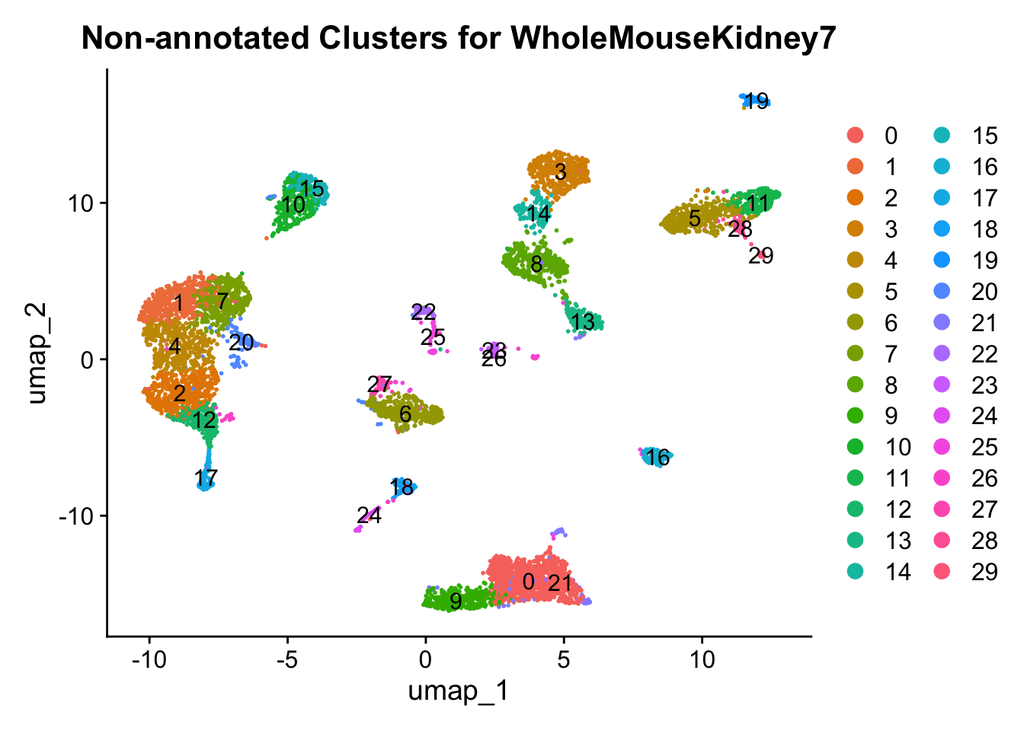

```r
seurat.obj.f_cleaned <- SCTransform(seurat.obj.f_cleaned) %>%
    RunPCA() %>%
    FindNeighbors(dims = 1:30) %>%
    FindClusters(resolution = 2, verbose = FALSE) %>%
    RunUMAP(dims = 1:30)

DimPlot(seurat.obj.f_cleaned, reduction = "umap", label = TRUE) +
  theme(plot.title = element_text(hjust = 0.5)) +
  ggtitle(paste0("Non-annotated Clusters for ", sample_name))
```

```r
DefaultAssay(seurat.obj.f_cleaned) <- "RNA"
```

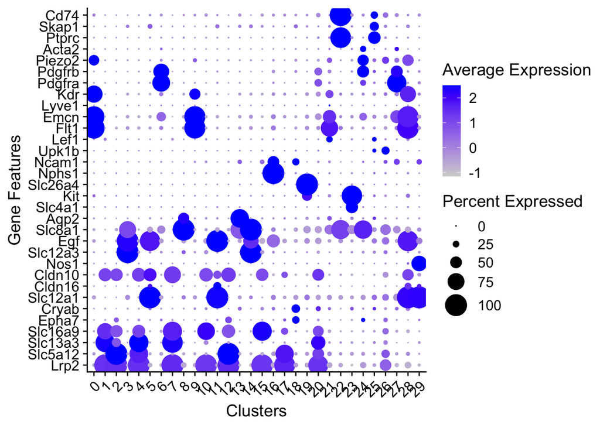

```r
# Make mdd for all removed doublets

DotPlot(seurat.obj.f_cleaned,
features = markers.to.plot1,
dot.scale = 8,
dot.min = 0,
scale.max = 100,
scale.min = 0,
col.min = -2.5,
col.max = 2.5) +
  theme(axis.text.x = element_text(angle = 45, hjust = 1)) +
  coord_flip() +
  labs(x = "Gene Features", y = "Clusters")
```

# **Manual** Doublet Filtering 2

### The Goal of This Step Is To Remove Doublets Not Identified by Manual 1

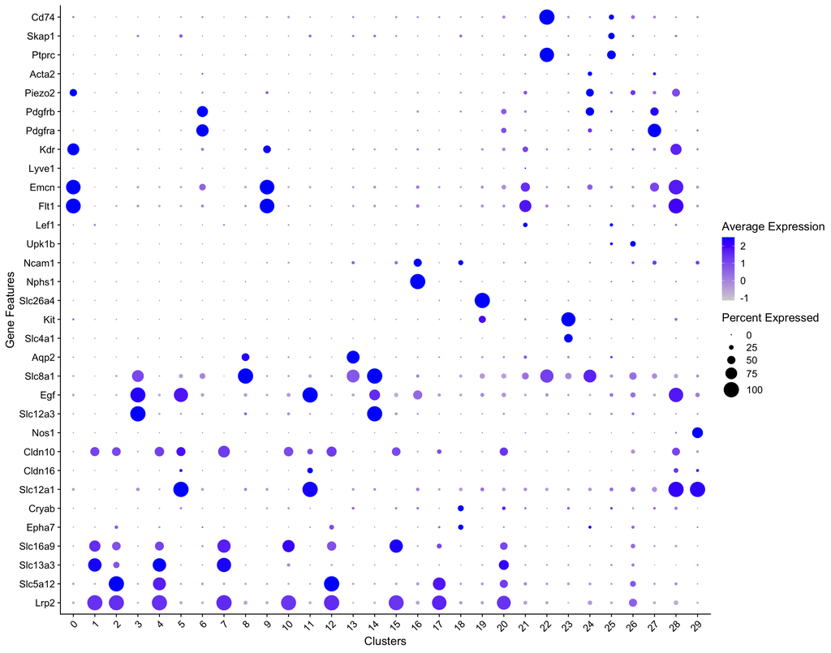

```r
# Creating a dot plot to cross reference the features with the cell clusters present, seeing the average expression and percent expressed

f11 <- DotPlot(seurat.obj.f_cleaned,
features = markers.to.plot1,
dot.scale = 8,
dot.min = 0,
scale.max = 100,
scale.min = 0,
col.min = -2.5,
col.max = 2.5) +
  theme(axis.text.x = element_text(angle = 45, hjust = 1)) +
  coord_flip() +
  labs(x = "Gene Features", y = "Clusters")

f11
```

## Clusters of Concern 2

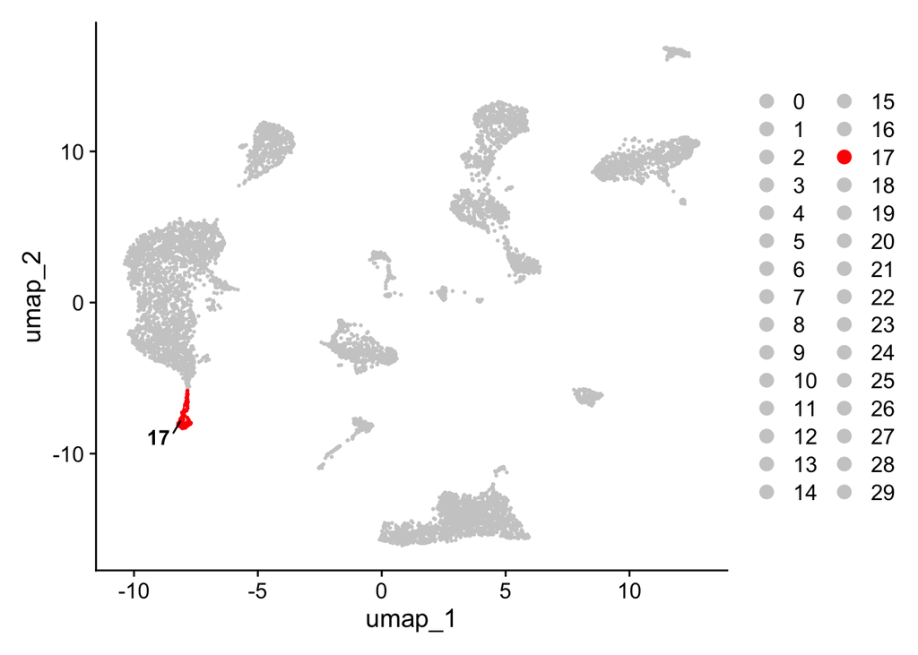

```r
f22 <- as.data.frame(f11$data)

maybe_doublets2 <- f22 %>%
  group_by(id) %>%
  filter(all(avg.exp.scaled <= 2.0)) %>%
  distinct(id) %>%
  pull(id)

maybe_doublets2

# Create color palette: grey for all, color for maybe_doublets2
all_clusters <- levels(seurat.obj.f_cleaned)
cluster_colors <- setNames(rep("grey80", length(all_clusters)), all_clusters)
cluster_colors[maybe_doublets2] <- "red"

# Get UMAP coordinates and cluster assignments
umap_data <- Embeddings(seurat.obj.f_cleaned, "umap") %>%
  as.data.frame() %>%
  mutate(cluster = Idents(seurat.obj.f_cleaned))

# Compute cluster centroids
cluster_centroids <- umap_data %>%
  group_by(cluster) %>%
  summarise(UMAP_1 = mean(umap_1), UMAP_2 = mean(umap_2))

# Keep only centroids for maybe_doublets2
label_data <- cluster_centroids %>%
  filter(cluster %in% maybe_doublets2)

# Plot
DimPlot(seurat.obj.f_cleaned, reduction = "umap", cols = cluster_colors) +
  ggrepel::geom_text_repel(
    data = label_data,
    aes(x = UMAP_1, y = UMAP_2, label = cluster),
    size = 4,
    color = "black",
    fontface = "bold",
    max.overlaps = Inf,
    box.padding = 0.5,
    point.padding = 0.5
  )
```

## **WARNING!** Clusters of Concern 2

Some clusters present are doublets, and one can identify such, as they express various gene markers with a low average expression.

```r
# Apply the name "SINGLET" or "DOUBLET" to a cluster based on the multidimensional dot plot

doublet_clusters <- c(28)

# Annotate metadata
seurat.obj.f_cleaned@meta.data <- seurat.obj.f_cleaned@meta.data %>%
  mutate(subclass.doublet = if_else(
    seurat_clusters %in% doublet_clusters, "DOUBLET", "SINGLET"
  ))

# Change the identities to align with new subclass names and make umap
Idents(seurat.obj.f_cleaned) <- seurat.obj.f_cleaned@meta.data$subclass.doublet

f11 <- DimPlot(seurat.obj.f_cleaned, reduction = "umap") +
  theme(plot.title = element_text(hjust = 0.5)) +
  ggtitle("Before Manual Doublet Filtering")
```

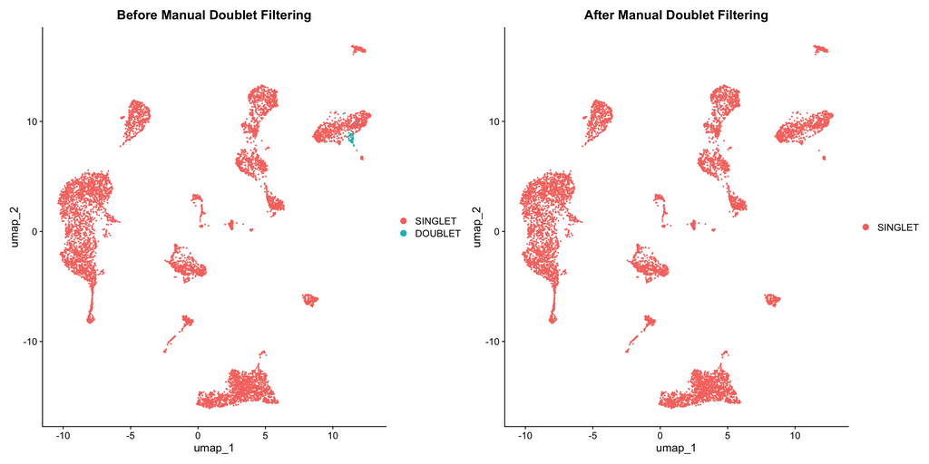

```r
# Double check the table to ensure SINGLET & DOUBLET cluster appear with this function
table(Idents(seurat.obj.f_cleaned))

# Clean out the doublets manually that were identified
seurat.obj.f_cleaned2 <- subset(seurat.obj.f_cleaned, idents = "DOUBLET", invert = TRUE)

# Double check that the identity was removed
table(Idents(seurat.obj.f_cleaned2))

# Make umap to double check removal
f22 <- DimPlot(seurat.obj.f_cleaned2, reduction = "umap") +
  theme(plot.title = element_text(hjust = 0.5)) +
  ggtitle("After Manual Doublet Filtering")

f11+f22
```

```r
# Remove unused objects in environment to save RAM
# rm(seurat.obj.f_cleaned)
```

## Re-Cluster Singlets 2

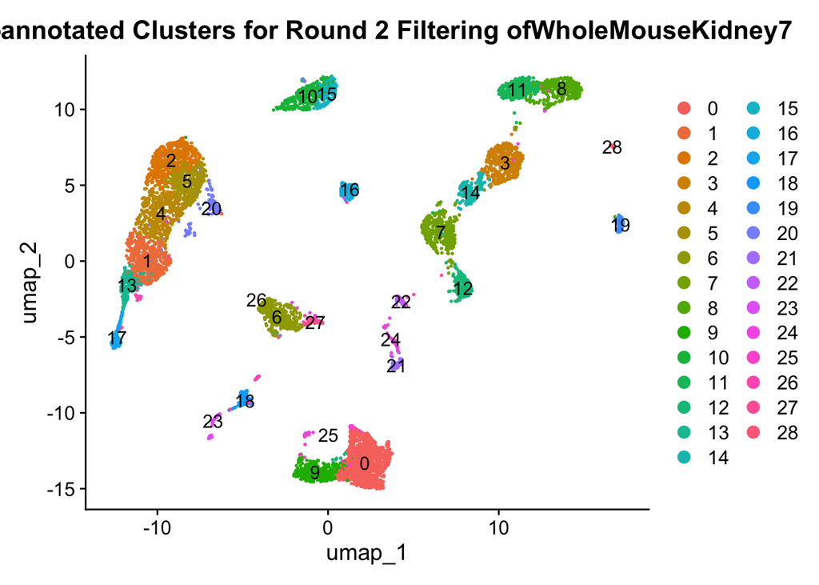

```r
seurat.obj.f_cleaned2 <- SCTransform(seurat.obj.f_cleaned2) %>%
    RunPCA() %>%
    FindNeighbors(dims = 1:30) %>%
    FindClusters(resolution = 2, verbose = FALSE) %>%
    RunUMAP(dims = 1:30)

DimPlot(seurat.obj.f_cleaned2, reduction = "umap", label = TRUE) +
  theme(plot.title = element_text(hjust = 0.5)) +
  ggtitle(paste0("Non-annotated Clusters for Round 2 Filtering of", sample_name))
```

```r
DefaultAssay(seurat.obj.f_cleaned2) <- "RNA"
```

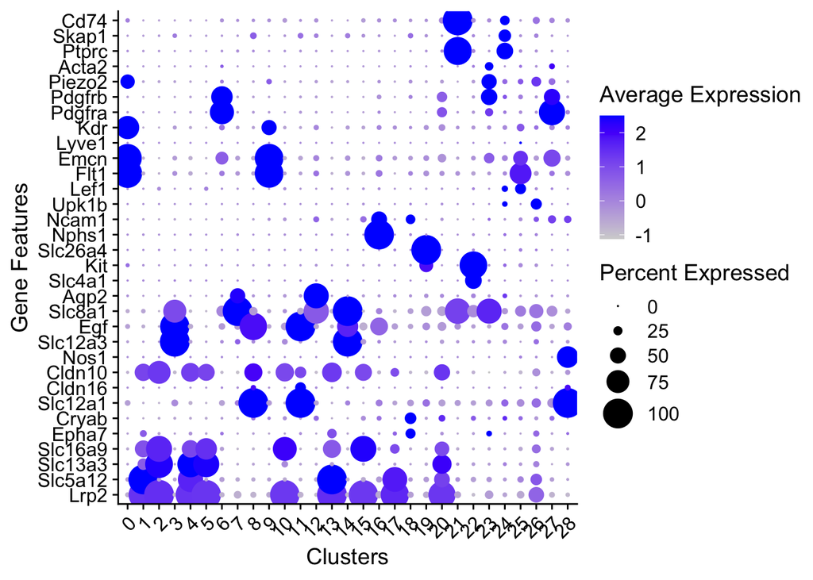

```r
# Make mdd for all removed doublets


DotPlot(seurat.obj.f_cleaned2,
features = markers.to.plot1,
dot.scale = 8,
dot.min = 0,
scale.max = 100,
scale.min = 0,
col.min = -2.5,
col.max = 2.5) +
  theme(axis.text.x = element_text(angle = 45, hjust = 1)) +
  coord_flip() +
  labs(x = "Gene Features", y = "Clusters")
```

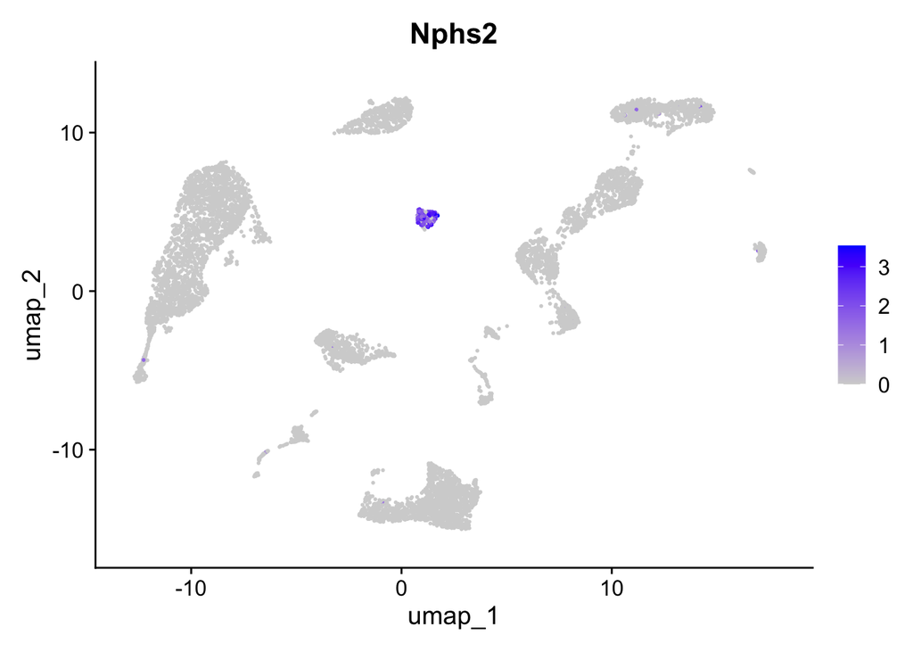

```r
FeaturePlot(seurat.obj.f_cleaned2, features = c("Nphs2"))
```

## Annotate by Subclass

Use the list of kidney markers in the table above to determine the identity of each of the clusters. Then in the code below, enter the name of the cluster (as shown in the table above).

For example, **Cluster 0** expresses **Flt1** and **Emcn**, which are **Endothelial Markers**. Therefore add **“EC”** into the line of code here: `seurat_clusters == 0 ~ "EC"` to annotate this cluster as “EC”

Then repeat for the rest of the clusters.

By using the **same cell type nomeclature** in the table, we will be able to **automatically annotate** the clusters at the **class** and **type** level and provide proportion plots.

If you notice that there are additional clusters that have **characteristics consistent with doublets**, then call them `DOUBLETS` and they will be filtered out at the end of this chunk. However, we do not recluster after this step, as we’ve found that the removal of this small number of cell doesn’t alter the clustering significantly.

## This Step Takes the Most Time

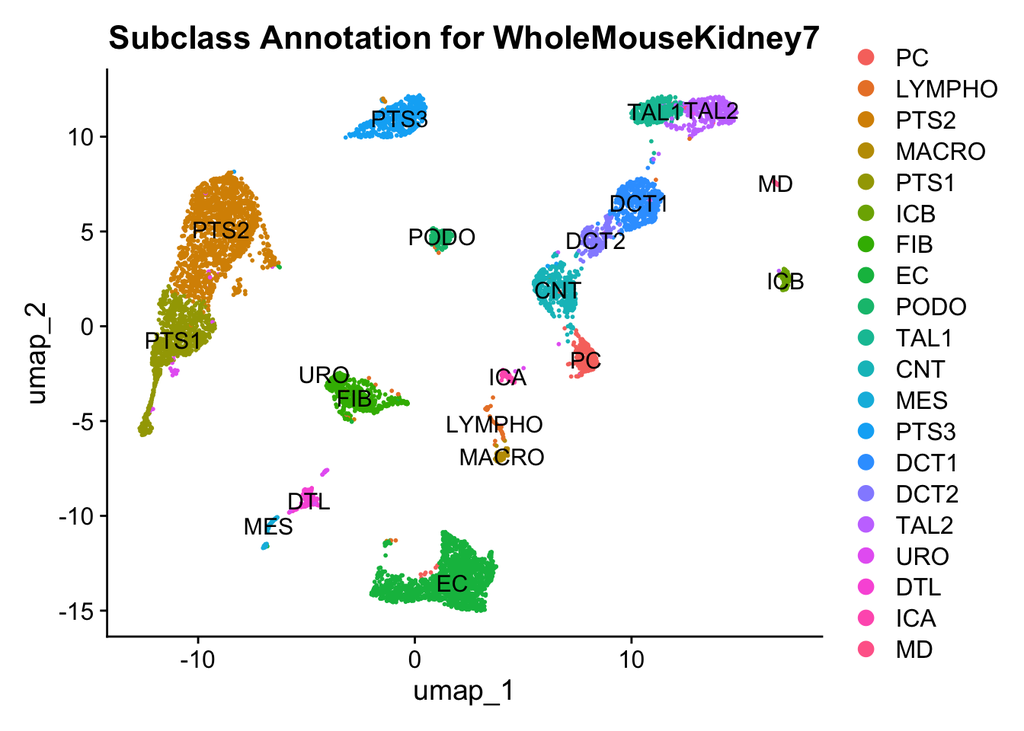

```r
# Apply names to the clusters by subclass
seurat.obj.f_cleaned2@meta.data <- seurat.obj.f_cleaned2@meta.data %>% mutate(subclass = dplyr::case_when(
seurat_clusters == 0 ~ "EC",
seurat_clusters == 1 ~ "PTS1",
seurat_clusters == 2 ~ "PTS2",
seurat_clusters == 3 ~ "DCT1",
seurat_clusters == 4 ~ "PTS2",
seurat_clusters == 5 ~ "PTS2",
seurat_clusters == 6 ~ "FIB",
seurat_clusters == 7 ~ "CNT",
seurat_clusters == 8 ~ "TAL2",
seurat_clusters == 9 ~ "EC",
seurat_clusters == 10 ~ "PTS3",
seurat_clusters == 11 ~ "TAL1",
seurat_clusters == 12 ~ "PC",
seurat_clusters == 13 ~ "PTS1",
seurat_clusters == 14 ~ "DCT2",
seurat_clusters == 15 ~ "PTS3",
seurat_clusters == 16 ~ "PODO",
seurat_clusters == 17 ~ "PTS1",
seurat_clusters == 18 ~ "DTL",
seurat_clusters == 19 ~ "ICB",
seurat_clusters == 20 ~ "PTS2",
seurat_clusters == 21 ~ "MACRO",
seurat_clusters == 22 ~ "ICA",
seurat_clusters == 23 ~ "MES",
seurat_clusters == 24 ~ "LYMPHO",
seurat_clusters == 25 ~ "EC",
seurat_clusters == 26 ~ "URO",
seurat_clusters == 27 ~ "FIB",
seurat_clusters == 28 ~ "MD"
))

# Filter out the doublets

seurat.obj.f_cleaned2 <- subset(seurat.obj.f_cleaned2, subset = subclass == "DOUBLET", invert = TRUE)

subclass_order <- c("PTS1", "PTS2", "PTS3", "DTL", "TAL1", "TAL2", "MD", "DCT1", "DCT2", "CNT", "PC", "ICA", "ICB", "PODO", "PEC", "URO", "EC", "FIB", "MES", "LYMPHO", "MACRO")

seurat.obj.f_cleaned@meta.data$subclass <- factor(seurat.obj.f_cleaned@meta.data$subclass, levels = subclass_order)

# Change the identities to align with new subclass names and make umap
Idents(seurat.obj.f_cleaned2) <- seurat.obj.f_cleaned2@meta.data$subclass

DimPlot(seurat.obj.f_cleaned2, reduction = "umap", label = TRUE, label.size = 4) +
  theme(plot.title = element_text(hjust = 0.5)) +
  ggtitle(paste0("Subclass Annotation for ", sample_name))
```

```r
Filter_3  <- ncol(seurat.obj.f_cleaned2)

amountfiltered3 <- Filter_2-Filter_3

#Making a table to display the amount of cells being filtered out with the minimal filtering of low quality cells applied to the snRNAseq dataset.
cell_counts <- data.frame(Phase = c("Before Filtering", "After Filtering", "Amount Filtered"), Cell_Number = c(Filter_2, Filter_3, amountfiltered3))

print(cell_counts)
```

**715 cells** were removed after **manual doublet filtering**.

## Save Excel Spreadsheet

### This code creates an Excel Spreadsheet of DEG List by Subtype

The file will be located in the **Outputs** folder.

```r
# Step 1: Find markers (grouped by subclass)
all_markers <- FindAllMarkers(
  seurat.obj.f_cleaned2,
  only.pos = TRUE,
  min.pct = 0.5,
  logfc.threshold = 1,
  group.by = "subclass"  # grouping by subclass instead of cluster ID
)

# Step 2: Sort markers by descending log2FC, put gene column first
all_markers <- all_markers %>%
  arrange(desc(avg_log2FC)) %>%
  select(gene, everything())

# Step 3: Split markers by subclass (stored in 'cluster' column still)
marker_list <- split(all_markers, all_markers$cluster)

# Step 4: Reorder the list according to your subclass_order
# First ensure you're only including subclasses that are actually present
valid_subclasses <- subclass_order[subclass_order %in% names(marker_list)]

# Reorder marker_list based on that
marker_list <- marker_list[valid_subclasses]

# Step 5: Write to Excel
wb <- createWorkbook()

for (subclass in names(marker_list)) {
  addWorksheet(wb, sheetName = subclass)
  writeData(wb, sheet = subclass, marker_list[[subclass]])
}

# Step 6: Save file
date <- format(Sys.Date(), "%Y%m%d")
saveWorkbook(
  wb,
  here("Outputs", paste0(date, "_", sample_name, "_FindAllMarkers_By_Subclass.xlsx")),
  overwrite = TRUE
)
```

## Characteristics if a Well Analyzed Kidney Dataset

### This Section is **Under Contruction**

### Example of Well-Annotated Whole Kidney Datasets

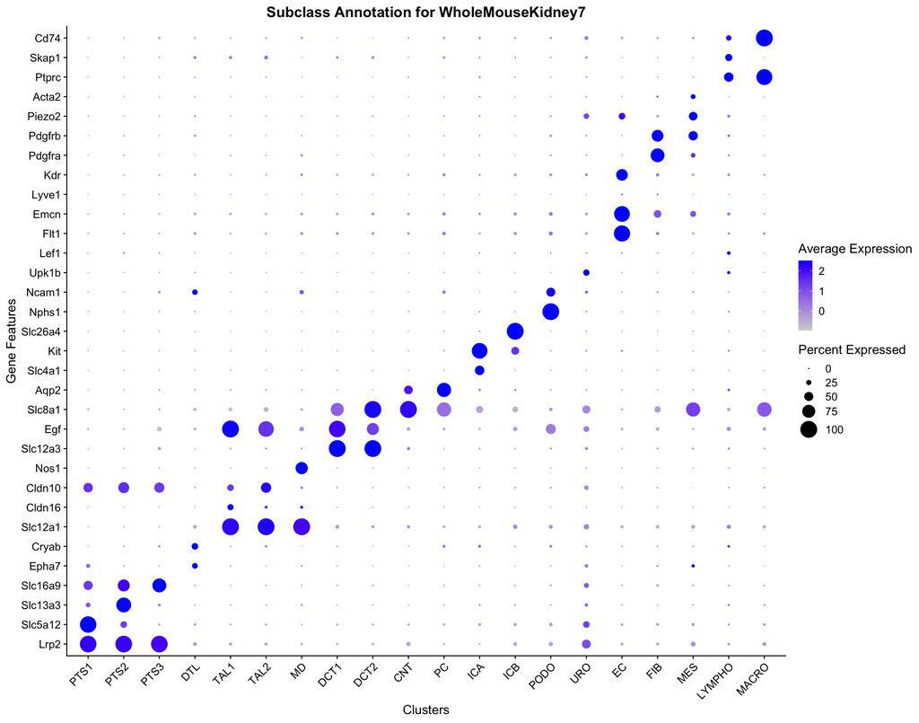

```r
# Change the order of the identities on the x-axis to create a diagonal on the dotplot, going from top to bottom of the "naming kidney cells" table
subclass_order <- c("PTS1", "PTS2", "PTS3", "DTL", "TAL1", "TAL2", "MD",
                   "DCT1", "DCT2", "CNT", "PC", "ICA", "ICB", "PODO", "PEC",
                   "URO", "EC", "FIB", "MES", "LYMPHO", "MACRO")
seurat.obj.f_cleaned2$subclass <- factor(seurat.obj.f_cleaned2$subclass, levels = subclass_order)
DotPlot(seurat.obj.f_cleaned2,
features = markers.to.plot1,
group.by = "subclass",
dot.scale = 8,
dot.min = 0,
scale.max = 100,
scale.min = 0,
col.min = -2.5,
col.max = 2.5) +
  theme(axis.text.x = element_text(angle = 45, hjust = 1)) +
  coord_flip() +
  labs(x = "Gene Features", y = "Clusters") +
  theme(plot.title = element_text(hjust = 0.5)) +
  ggtitle(paste0("Subclass Annotation for ", sample_name))
```

## Annotate by Class

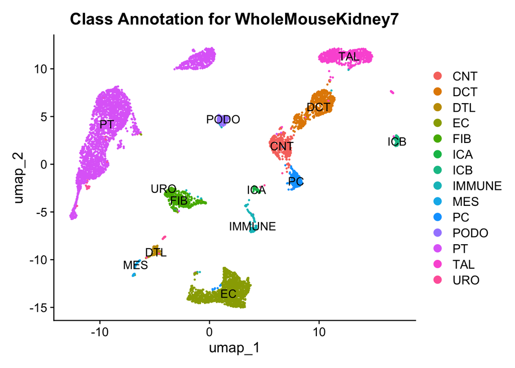

```r
# Change the specificty of the cells to a lower level and make another UMAP
seurat.obj.f_cleaned2@meta.data <- seurat.obj.f_cleaned2@meta.data %>%
  mutate(class = dplyr::case_when(
    subclass %in% c("PTS1", "PTS2", "PTS3") ~ "PT",
    subclass == "DTL" ~ "DTL",
    subclass %in% c("TAL1", "TAL2", "MD") ~ "TAL",
    subclass %in% c("DCT1", "DCT2") ~ "DCT",
    subclass == "CNT" ~ "CNT",
    subclass == "PC" ~ "PC",
    subclass == "ICA" ~ "ICA",
    subclass == "ICB" ~ "ICB",
    subclass == "PODO" ~ "PODO",
    subclass == "PEC" ~ "PEC",
    subclass == "URO" ~ "URO",
    subclass %in% c("EC", "ECG", "ECP", "LYMPH") ~ "EC",
    subclass == "FIB" ~ "FIB",
    subclass == "MES" ~ "MES",
    subclass == "VSMC" ~ "VSMC",
    subclass %in% c("LYMPHO", "MACRO") ~ "IMMUNE",
    subclass %in% c("Unknown") ~ "Unknown",
  ))

DimPlot(seurat.obj.f_cleaned2, group.by = "class", label = TRUE, label.size = 4) +
   theme(plot.title = element_text(hjust = 0.5)) +
   ggtitle(paste0("Class Annotation for ", sample_name))
```

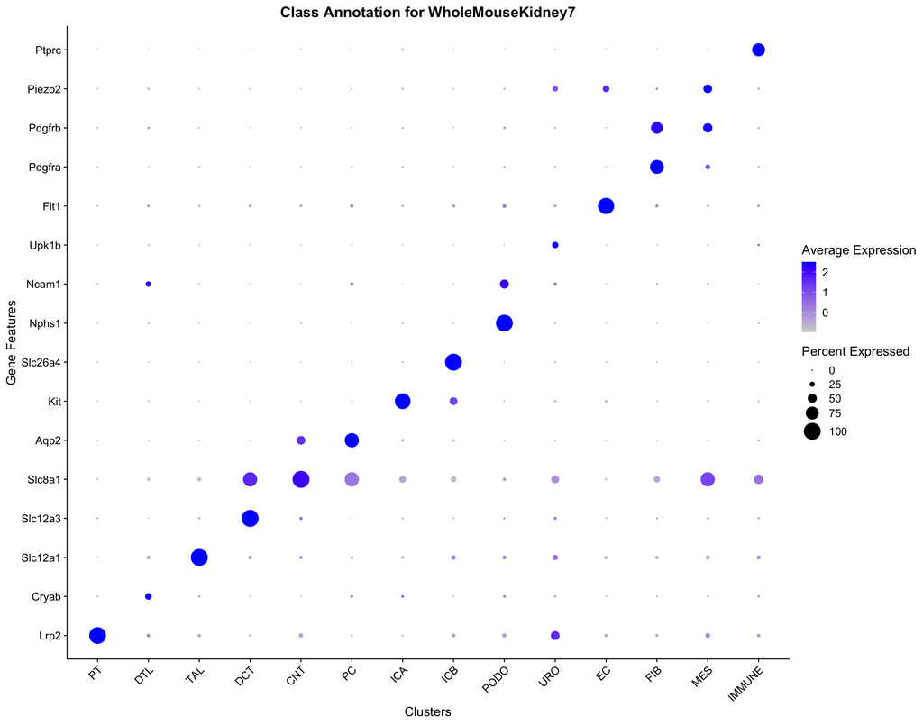

```r
class_order <- c("PT", "DTL", "TAL", "DCT", "CNT", "PC", "ICA", "ICB", "PODO", "PEC", "URO", "EC", "FIB", "MES", "IMMUNE")
seurat.obj.f_cleaned2@meta.data$class <- factor(seurat.obj.f_cleaned2@meta.data$class, levels = class_order)

markers.to.plot2 <- c("Lrp2",         # PTS1, PTS2, PTS3
                      "Cryab",        # DTL
                      "Slc12a1",      # TAL1, TAL2, MD
                      "Slc12a3",      # DCT1, DCT2
                      "Slc8a1",       # CNT
                      "Aqp2",         # PC
                      "Kit",          # ICA
                      "Slc26a4",      # ICB
                      "Nphs1",        # PODO
                      "Ncam1",        # PEC
                      "Upk1b",        # URO
                      "Flt1",         # EC
                      "Pdgfra",       # FIB
                      "Pdgfrb",       # FIB, MES, VSMC
                      "Piezo2",       # MES
                      "Ptprc"        # LYMPHO, MACRO
)

DotPlot(seurat.obj.f_cleaned2,
features = markers.to.plot2,
group.by = "class",
dot.scale = 8,
dot.min = 0,
scale.max = 100,
scale.min = 0,
col.min = -2.5,
col.max = 2.5) +
  theme(axis.text.x = element_text(angle = 45, hjust = 1)) +
  coord_flip() +
  labs(x = "Gene Features", y = "Clusters") +
  theme(plot.title = element_text(hjust = 0.5)) +
  ggtitle(paste0("Class Annotation for ", sample_name))
```

## Annotate by Type

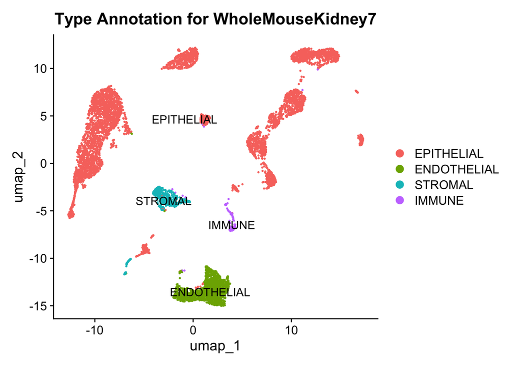

```r
# Change the specificty of the cells to a further lower level and make another UMAP
seurat.obj.f_cleaned2@meta.data <- seurat.obj.f_cleaned2@meta.data %>%
  mutate(type = dplyr::case_when(
    class %in% c("PT", "DTL", "TAL", "DCT", "CNT", "PC", "ICA", "ICB", "PODO", "PEC", "URO") ~ "EPITHELIAL",
    class == "EC" ~ "ENDOTHELIAL",
    class %in% c("FIB", "MES", "VSMC") ~ "STROMAL",
    class == "IMMUNE" ~ "IMMUNE",
  ))

type_order <- c("EPITHELIAL", "ENDOTHELIAL", "STROMAL", "IMMUNE")
seurat.obj.f_cleaned2@meta.data$type <- factor(seurat.obj.f_cleaned2@meta.data$type, levels = type_order)

DimPlot(seurat.obj.f_cleaned2, group.by = "type", label = TRUE, label.size = 4) +
  theme(plot.title = element_text(hjust = 0.5)) +
  ggtitle(paste0("Type Annotation for ", sample_name))
```

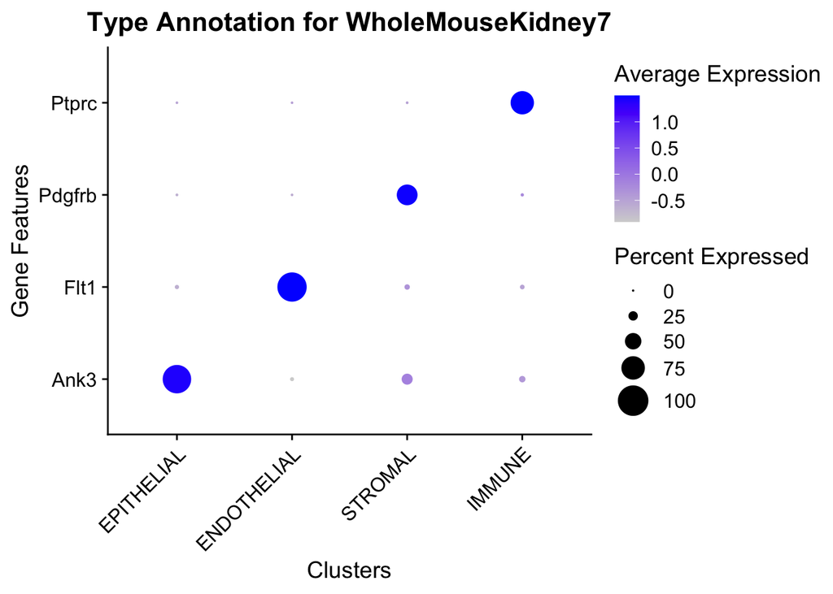

```r
type_order <- c("EPITHELIAL", "ENDOTHELIAL", "STROMAL", "IMMUNE")
seurat.obj.f_cleaned2@meta.data$type <- factor(seurat.obj.f_cleaned2@meta.data$type, levels = type_order)

markers.to.plot3 <- c("Ank3",         # PTS1, PTS2, PTS3, DTL, TAL1, TAL2, MD, DCT1, DCT2, CNT, PC, ICA, ICB, PODO, PEC, URO
                      "Flt1",         # EC
                      "Pdgfrb",       # FIB, MES, VSMC
                      "Ptprc"         # LYMPHO, MACRO
)

DotPlot(seurat.obj.f_cleaned2,
features = markers.to.plot3,
group.by = "type",
dot.scale = 8,
dot.min = 0,
scale.max = 100,
scale.min = 0,
col.min = -2.5,
col.max = 2.5) +
  theme(axis.text.x = element_text(angle = 45, hjust = 1)) +
  coord_flip() +
  labs(x = "Gene Features", y = "Clusters") +
  theme(plot.title = element_text(hjust = 0.5)) +
  ggtitle(paste0("Type Annotation for ", sample_name))
```

## Proportion Plots for **WholeMouseKidney7**

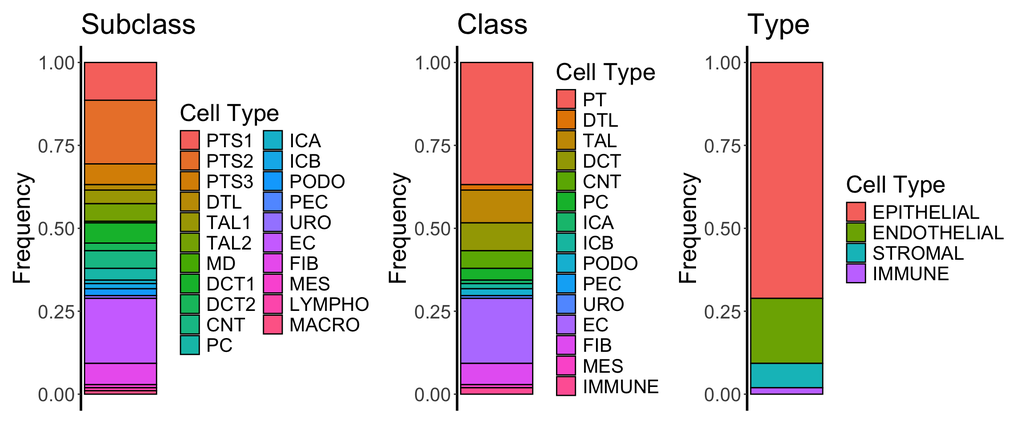

```r
t1 <- table(seurat.obj.f_cleaned2@meta.data$subclass)
#t1

prop.t1 <- prop.table(t1)
#prop.t1

t2 <- as.data.frame(t1)
colnames(t2) <- c('Cell_type', 'Frequency')

# Original plot

f1a <- ggplot(t2, aes(fill=Cell_type, y=Frequency, x=1)) +
  geom_bar(position="fill", stat = "identity", fun.y = "mean", colour="black") +
  theme_classic() +
  theme(axis.line = element_line(size = 1, colour = "black"),
        axis.text.x = element_blank(),
        axis.ticks.x = element_blank(),
        panel.grid.major.x = element_blank(),
        panel.grid.minor.x = element_blank(),
        panel.border = element_blank(),
        panel.background = element_blank(),
        text = element_text(size=20),
        axis.line.x = element_blank()) +
  labs(fill = "Cell Type") +
  xlab(NULL) + ggtitle("Subclass")

t1 <- table(seurat.obj.f_cleaned2@meta.data$class)
#t1

prop.t1 <- prop.table(t1)
#prop.t1

t2 <- as.data.frame(t1)
colnames(t2) <- c('Cell_type', 'Frequency')

# Original plot

f1b <- ggplot(t2, aes(fill=Cell_type, y=Frequency, x=1)) +
  geom_bar(position="fill", stat = "identity", fun.y = "mean", colour="black") +
  theme_classic() +
  theme(axis.line = element_line(size = 1, colour = "black"),
        axis.text.x = element_blank(),
        axis.ticks.x = element_blank(),
        panel.grid.major.x = element_blank(),
        panel.grid.minor.x = element_blank(),
        panel.border = element_blank(),
        panel.background = element_blank(),
        text = element_text(size=20),
        axis.line.x = element_blank()) +
  labs(fill = "Cell Type") +
  xlab(NULL) + ggtitle("Class")

t1 <- table(seurat.obj.f_cleaned2@meta.data$type)
#t1

prop.t1 <- prop.table(t1)
#prop.t1

t2 <- as.data.frame(t1)
colnames(t2) <- c('Cell_type', 'Frequency')

# Original plot

f1c <- ggplot(t2, aes(fill = Cell_type, y = Frequency, x = 1)) +
  geom_bar(position = "fill", stat = "identity", colour = "black") +
  theme_classic() +
  theme(
    axis.line = element_line(size = 1, colour = "black"),
    axis.text.x = element_blank(),
    axis.ticks.x = element_blank(),
    panel.grid.major.x = element_blank(),
    panel.grid.minor.x = element_blank(),
    panel.border = element_blank(),
    panel.background = element_blank(),
    text = element_text(size = 20),
    axis.line.x = element_blank()
  ) +
  labs(fill = "Cell Type") +
  xlab(NULL) +
  ggtitle("Type")


f1a + f1b +f1c
```

# **QC Reports**

## Progression of cells Filtering Through the Analysis of **WholeMouseKidney7**

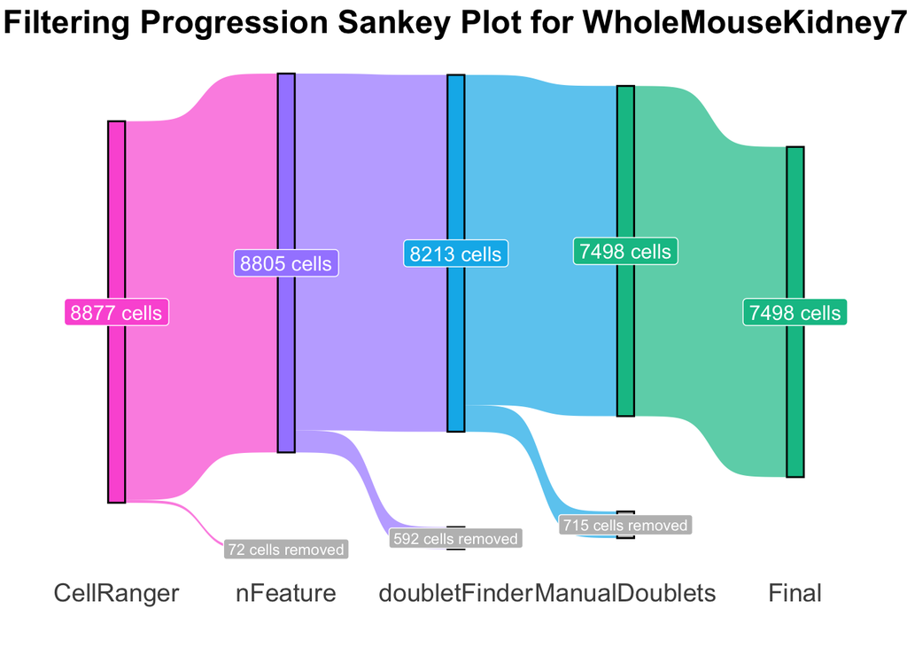

```r
Start_name <- paste0(as.character(Start), " cells")
Filter_1_name <- paste0(as.character(Filter_1), " cells")
Filter_2_name <- paste0(as.character(Filter_2), " cells")
Filter_3_name <- paste0(as.character(Filter_3), " cells")


df_paths2 <- data.frame(
  group = c("Pass_All", "Filtered_at_3", "Filtered_at_2", "Filtered_at_1"),
  CellRanger = c(Start_name,     Start_name,       Start_name,        Start_name),
  nFeature = c(Filter_1_name,  Filter_1_name,    Filter_1_name,     paste0(as.character(Start-Filter_1), " cells removed")),
  doubletFinder = c(Filter_2_name,  Filter_2_name,   paste0(as.character(Filter_1-Filter_2), " cells removed"),    NA),
  ManualDoublets = c(Filter_3_name, paste0(as.character(Filter_2-Filter_3), " cells removed"),      NA,       NA),
  value = c(Start,        Filter_2-Filter_3,          Filter_1-Filter_2,           Start-Filter_1)
)


df_paths2b <- data.frame(
  group = c("Pass_All", "Filtered_at_3", "Filtered_at_2", "Filtered_at_1"),
  CellRanger = c(Start_name, Start_name, Start_name, Start_name),
  nFeature = c(Filter_1_name, Filter_1_name, Filter_1_name, paste0(as.character(Start - Filter_1), " cells removed")),
  doubletFinder = c(Filter_2_name, Filter_2_name, paste0(as.character(Filter_1 - Filter_2), " cells removed"), NA),
  ManualDoublets = c(Filter_3_name, paste0(as.character(Filter_2 - Filter_3), " cells removed"), NA, NA),
  Final = c(Filter_3_name , NA, NA, NA),
  value = c(Start, Filter_2 - Filter_3, Filter_1 - Filter_2, Start - Filter_1)
)

# Convert to long format suitable for ggsankey
df_sankey <- df_paths2b   %>%
  make_long(CellRanger, nFeature, doubletFinder, ManualDoublets, Final, value = "value")

# make removed nodes gray
orig_levels <- levels(factor(df_sankey$node))
orig_palette <- scales::hue_pal()(length(orig_levels))
names(orig_palette) <- orig_levels

# Override only "removed" nodes to gray
custom_palette <- orig_palette
custom_palette[grepl("removed", names(custom_palette))] <- "gray"

# change font size of removed nodes
df_sankey <- df_sankey %>%
  filter(!is.na(node))%>%
  mutate(is_removed = grepl("removed", node),
         label_size = ifelse(is_removed, 3, 4))

# specify order
df_sankey$node <- factor(df_sankey$node, levels = rev(unique(df_sankey$node)))
df_sankey$next_node <- factor(df_sankey$next_node, levels = rev(unique(df_sankey$node)))

# Do the same for next_node
df_sankey$next_node <- factor(df_sankey$next_node, levels = levels(df_sankey$node))


# Plot
ggplot(df_sankey, aes(x = x,
                      next_x = next_x,
                      node = node,
                      next_node = next_node,
                      value = value,
                      fill = factor(node))) +
  geom_sankey(flow.alpha = 0.7, node.color = "black") +
  geom_sankey_label(aes(label = node, size = label_size), color = "white", show.legend = FALSE) +
  scale_fill_manual(values = custom_palette) +
  scale_color_identity() +
  scale_size_identity() +
  theme_classic() +
labs(
  title = paste0("Filtering Progression Sankey Plot for ", sample_name),
  x = ""
) +
  theme(
    # Remove Y-axis
    axis.text.y = element_blank(),
    axis.ticks.y = element_blank(),
    axis.line.y = element_blank(),
    axis.title.y = element_blank(),
    panel.grid.major.y = element_blank(),
    panel.grid.minor.y = element_blank(),

    # Remove X-axis lines
    axis.line.x = element_blank(),
    axis.ticks.x = element_blank(),
    panel.grid.major.x = element_blank(),
    panel.grid.minor.x = element_blank(),

    # Enlarge text
    axis.text.x = element_text(size = 14),
    axis.title.x = element_text(size = 16),
    plot.title = element_text(size = 18, face = "bold", hjust = 0.5),

    # Hide legend
    legend.position = "none"
  )
```

## Subclass Cell Types That Were Not Annotated in **WholeMouseKidney7**

```r
list1 <- unique(seurat.obj.f_cleaned2$subclass)

list2 <- unique(markers_long$Subclass)

missing_subclass <- setdiff(list2, list1)

missing_subclass
```

The following subclasses were not annotated in this sample: **TALA, TALB, PEC, LYMPH, VSMC**

#PHATE

```r
# install.packages("phateR")
# Only need to do this once:
if (!requireNamespace("phateR", quietly=TRUE)) {
  install.packages("phateR")
}

# In every session:
library(phateR)
library(Seurat)
```

```r
#install.packages("reticulate")
library(reticulate)

# Pick a Python version (3.9 or 3.10 is fine)
conda_create("scvi_env", python_version = "3.9")

# Install scvi-tools (and its dependencies)
conda_install(
  envname  = "scvi_env",
  packages = c("scvi-tools", "anndata", "scanpy"),
  channel  = "conda-forge"
)

# Tell reticulate to use it
use_condaenv("scvi_env", required = TRUE)

# Verify that Python and R now match
py_config()
```

```r
# 2. grab your PCA embedding (or raw counts / normalized data if you prefer)
pca_mat <- Embeddings(seurat.obj.f_cleaned2, "pca")[, 1:30]


# 3. run PHATE (knn and t can be tuned)
phate_out <- phate(
  data   = pca_mat,
  n_components = 2,
  knn     = 10,
  t       = "auto"
)

# 4. build a data.frame of the 2-dim embedding
phate_df <- as.data.frame(phate_out$embedding)
colnames(phate_df) <- c("PHATE1", "PHATE2")
rownames(phate_df) <- colnames(seurat.obj.f_cleaned2)

# 5. add it to your Seurat object
seurat.obj.f_cleaned2[["phate"]] <- CreateDimReducObject(
  embeddings = phate_df,
  key        = "PHATE_",
  assay      = "RNA"
)
```

### Ambient RNA Warning for **WholeMouseKidney7**

Ambient RNA levels are acceptable.

# **Save** Seurat Object

## Add Sample Meta.Data to Object

It **matches** the column `Sample_ID` in the spreadsheet with the `sample_name` input in the **Set the Sample Name chunk**.

```r
meta <- read.xlsx(here("datasets", "metadata.xlsx"), sheet = 1)

meta$sample_name <- as.character(meta$sample_name)

seurat.obj.f_cleaned2@meta.data$sample <- sample_name

df <- FetchData(seurat.obj.f_cleaned2, "sample") %>% rownames_to_column(var = "CellID")

df <- left_join(df, meta, by = c("sample" = "sample_name")) %>% column_to_rownames(var = "CellID")

seurat.obj.f_cleaned2<- AddMetaData(seurat.obj.f_cleaned2, df)

seurat.obj.f_cleaned2
```

```
## An object of class Seurat
## 52687 features across 7498 samples within 2 assays
## Active assay: RNA (32285 features, 2000 variable features)
##  3 layers present: counts, data, scale.data
##  1 other assay present: SCT
##  2 dimensional reductions calculated: pca, umap
```

### **Check** to see if **Meta.Data has been added** to Seurat Object

**Scroll to the right** on the table to check for new meta.data columns.

```r
head(seurat.obj.f_cleaned2@meta.data)
```

|  | orig.ident | nCount_RNA | nFeature_RNA | RNA_snn_res.2 | seurat_clusters | pANN | DF.class | subclass.doublet | nCount_SCT | nFeature_SCT | SCT_snn_res.2 | subclass | class | type | sample | sample_description | cell_type | species | class_angII | class_time | class_angII_time | batch |
| --- | --- | --- | --- | --- | --- | --- | --- | --- | --- | --- | --- | --- | --- | --- | --- | --- | --- | --- | --- | --- | --- | --- |
| AAACCCAAGGAAGTGA-1 | SeuratProject | 3597.907 | 1762 | 11 | 12 | 0.2449339 | Singlet | SINGLET | 3561 | 1739 | 12 | PC | PC | EPITHELIAL | WholeMouseKidney7 | WT | Kidney | Mice | Veh | 5d | Veh_5d | 3 |
| AAACCCACACTACAGT-1 | SeuratProject | 1698.815 | 1104 | 24 | 24 | 0.1718062 | Singlet | SINGLET | 3355 | 1090 | 24 | LYMPHO | IMMUNE | IMMUNE | WholeMouseKidney7 | WT | Kidney | Mice | Veh | 5d | Veh_5d | 3 |
| AAACCCACAGGTGGAT-1 | SeuratProject | 5832.071 | 2426 | 2 | 5 | 0.2725404 | Singlet | SINGLET | 4007 | 2332 | 5 | PTS2 | PT | EPITHELIAL | WholeMouseKidney7 | WT | Kidney | Mice | Veh | 5d | Veh_5d | 3 |
| AAACCCAGTCGTACTA-1 | SeuratProject | 1199.155 | 876 | 24 | 21 | 0.1615272 | Singlet | SINGLET | 3384 | 871 | 21 | MACRO | IMMUNE | IMMUNE | WholeMouseKidney7 | WT | Kidney | Mice | Veh | 5d | Veh_5d | 3 |
| AAACCCATCGTTACCC-1 | SeuratProject | 7900.993 | 2795 | 8 | 2 | 0.2654919 | Singlet | SINGLET | 2793 | 1043 | 2 | PTS2 | PT | EPITHELIAL | WholeMouseKidney7 | WT | Kidney | Mice | Veh | 5d | Veh_5d | 3 |
| AAACCCATCTAGGAAA-1 | SeuratProject | 16104.847 | 4711 | 2 | 2 | 0.2969163 | Singlet | SINGLET | 2827 | 1374 | 2 | PTS2 | PT | EPITHELIAL | WholeMouseKidney7 | WT | Kidney | Mice | Veh | 5d | Veh_5d | 3 |

## This saves the Seurat Object as an .RDS file

This **file is processed** and can be **merged with replicates** in downstream analysis.

It will be saved in the **Outputs** folder.

```r
# Add a date to file name
date <- format(Sys.Date(), "%Y%m%d")

#saveRDS(seurat.obj.f_cleaned2, here("Outputs", paste0(date, sample, ".rds")))
```

# **Acknowledgements**

## Group Leaders

This guide is written based on the experience of multiple trainee’s and investigators

These include:

Michael Hutchens  
Susan Gurley

## Trainees

Trainee’s that contributed to the thinking that went into this guide include:

Roman Thomas  
Kevin Burfeind  
Xiao-Tong Su  
Annie Lackey  
Jeremiah Reyes  
Sienna Blanche  
Jeff Karnsomprot